# TCI-PDI Analysis

This is the analysis for the preprint “Dopamine D1 receptor availability is not associated with delusional ideation measures of psychosis proneness”. Some of the data is considered sensitive, and it will not be possible for it to be shared openly due to regulatory restrictions. We are currently in discussions with the institution to ask whether the current interpretation of the regulation can or will be changed. I will upload as much of the data as I can before submission.

Another little note: I spotted a couple of small errors in the code following submission to bioRxiv. Some of the values differ at a decimal point or two from the current version on bioRxiv, but the conclusions are unchanged.

# Setup

```r
library(tidyverse)
library(broom)
library(readxl)
library(knitr)
library(ggplot2)
library(pander)
library(R2jags)
library(truncnorm)
library(polspline)
library(stringr)
library(viridis)
library(RColorBrewer)
library(psych)
library(stringr)
library(ggridges)
library(forcats)
# library(bayesplot)
# bayesplot::color_scheme_set("viridis")

distroplot_norm <- function(fitobject, variable.name, priormean, priorsd, nbin=50) {

  samples <- tibble(Posterior = as.numeric(fitobject$BUGSoutput$sims.list[[variable.name]]))

  parameters <- fitobject$model$data()

  priormean_val <- ifelse(is.character(priormean), parameters[[priormean]], priormean)
  priorsd_val <- ifelse(is.character(priorsd), parameters[[priorsd]], priorsd)

  out <- ggplot(samples, aes(x=Posterior)) +
    geom_histogram(aes(y = ..density.., colour="Posterior"), bins=nbin, fill="white") +
    stat_function(fun = dnorm, args = list(mean = priormean_val, sd=priorsd_val), aes(colour='Prior'), size=2) +
    stat_function(fun = dnorm, args = list(mean = priormean_val, sd=priorsd_val), color="white", size=1) +
    geom_line(aes(y = ..density.., colour="Posterior"), size=2, stat="density") +
    geom_line(aes(y = ..density..), colour="white", size=1, stat="density") +
    geom_vline(xintercept=mean(samples$Posterior), linetype = "dashed", size=1) +
    scale_colour_viridis(begin=0,direction=1, end=0.66, discrete=T, 'Distribution') +
    expand_limits(x=c(priormean_val - priorsd_val, priormean_val + priorsd_val)) +
    labs(y='Probability Density', x='Parameter Value')

  return(out)

}

distroplot_norm_perc <- function(fitobject, variable.name, priormean, priorsd, meanscale, nbin=50) {

  samples <- tibble(Posterior = as.numeric(fitobject$BUGSoutput$sims.list[[variable.name]]))

  parameters <- fitobject$model$data()

  priormean_val <- ifelse(is.character(priormean), parameters[[priormean]], priormean)
  priorsd_val <- ifelse(is.character(priorsd), parameters[[priorsd]], priorsd)

  samples$Posterior <- 100*samples$Posterior/meanscale
  priormean_val <- 100*priormean_val/meanscale
  priorsd_val <- 100*priorsd_val/meanscale

  out <- ggplot(samples, aes(x=Posterior)) +
    geom_histogram(aes(y = ..density.., colour="Posterior"), bins=nbin, fill="white") +
    stat_function(fun = dnorm, args = list(mean = priormean_val, sd=priorsd_val), aes(colour='Prior'), size=2) +
    stat_function(fun = dnorm, args = list(mean = priormean_val, sd=priorsd_val), color="white", size=1) +
    geom_line(aes(y = ..density.., colour="Posterior"), size=2, stat="density") +
    geom_line(aes(y = ..density..), colour="white", size=1, stat="density") +
    geom_vline(xintercept=mean(samples$Posterior), linetype = "dashed", size=1) +
    scale_colour_viridis(begin=0,direction=1, end=0.66, discrete=T, 'Distribution') +
    expand_limits(x=c(priormean_val - priorsd_val, priormean_val + priorsd_val)) +
    labs(y='Probability Density', x='Parameter Value (%)')

  return(out)

}

set.seed(12345)
```

# Aims

This study aims to evaluate the relationship between D1 Receptor BP<sub>ND</sub> evaluated using [11C]SCH-23390 and measures of delusional proneness. We also aimed to validate a potential alternative scale to measure delusional proneness using items from the TCI Spiritual Acceptance subscale, many of whose items are relatively similar to items belonging to the PDI scale.

# Substudy 1A: TCI-PDI Questionnaire Validation

We aimed to select questions from the TCI Spiritual Acceptance scale which were more indicative of psychotic proneness, in a manner similar to the Peters Delusion Inventory. Items were first selected from the scale which sounded like PDI items (i.e. showed face validity). They were then psychometrically evaluated in an independent data set of 132 individuals. In the end, we came up with two alternative implementations of a TCI-psychotic proneness scale: one longer but less specific (aiming for maximising reliability), and one shorter but more specific (aiming for maximising validity), and their psychometric validity was assessed.

```r
TCIdf<-read.csv('../RawData_Clean/tcivalidation_data.csv')

psych::describe(TCIdf$Age)
```

```
##    vars   n  mean   sd median trimmed   mad min max range  skew kurtosis  se
## X1    1 132 47.94 16.1     50   47.88 19.27  22  76    54 -0.04    -1.25 1.4
```

```r
table(TCIdf$Sex)
```

```
##
## Kvinna Man
##     72     60
```

```r
tcipdiLong_items <- c(6, 15, 38, 51, 56, 76, 77, 97, 116, 175, 194, 200, 208, 220) # This list revised: see later --> -56 and -220
tcipdiLong_items <- str_pad(tcipdiLong_items, 3, 'left', '0')

tcipdiShort_items <- c(56, 76, 77, 97, 116, 175, 200, 208)
tcipdiShort_items <- str_pad(tcipdiShort_items, 3, 'left', '0')

TCIPDIdf <- TCIdf %>%
  select(IdNR, Time_Stamp, Age, one_of(paste0('TCI', tcipdiLong_items))) %>%
  mutate(TCI220 = 1+(TCI220*-1)) # Reversed

TCIPDI_Longdf_items <- TCIPDIdf %>%
  select(starts_with('TCI'))

TCIPDI_Shortdf_items <- TCIPDI_Longdf_items %>%
  select(one_of(paste0('TCI', tcipdiShort_items)))
```

## Psychometric Validation: TCIPDI_long

This scale corresponds to a longer, and slightly less specific list of questions, but for which we focus on attaining high psychometric reliability.

### Correlation Matrix

```r
cormatrix <- cor(TCIPDI_Longdf_items)
cormatrix <- ifelse(cormatrix!=1, cormatrix, NA)
knitr::kable(cormatrix[,1:7])
```

|  | TCI006 | TCI015 | TCI038 | TCI051 | TCI056 | TCI076 | TCI077 |
| --- | --- | --- | --- | --- | --- | --- | --- |
| TCI006 | NA | 0.1407123 | 0.2693123 | 0.2131602 | 0.1413524 | 0.3268344 | 0.2903800 |
| TCI015 | 0.1407123 | NA | 0.2053818 | 0.2802713 | 0.2228490 | 0.3149965 | 0.1797491 |
| TCI038 | 0.2693123 | 0.2053818 | NA | 0.2392834 | 0.1328656 | 0.2147594 | 0.3099255 |
| TCI051 | 0.2131602 | 0.2802713 | 0.2392834 | NA | 0.0986258 | 0.3716854 | 0.1599805 |
| TCI056 | 0.1413524 | 0.2228490 | 0.1328656 | 0.0986258 | NA | -0.0187317 | 0.1673320 |
| TCI076 | 0.3268344 | 0.3149965 | 0.2147594 | 0.3716854 | -0.0187317 | NA | 0.4253850 |
| TCI077 | 0.2903800 | 0.1797491 | 0.3099255 | 0.1599805 | 0.1673320 | 0.4253850 | NA |
| TCI097 | 0.4889012 | 0.3026364 | 0.3591673 | 0.3341594 | 0.0790569 | 0.4738791 | 0.4466853 |
| TCI116 | 0.3290430 | 0.0874600 | 0.4411737 | 0.1890352 | 0.1760289 | 0.2010563 | 0.2822369 |
| TCI175 | 0.3042237 | 0.1883185 | 0.1882128 | 0.2287911 | 0.4372397 | 0.1964713 | 0.3292691 |
| TCI194 | 0.3991289 | 0.2759269 | 0.2429846 | 0.1475861 | -0.0063969 | 0.3085506 | 0.3173005 |
| TCI200 | 0.4093284 | 0.3143016 | 0.1616869 | 0.2913232 | 0.1316561 | 0.4837438 | 0.3752411 |
| TCI208 | 0.4569381 | 0.2828508 | 0.1673006 | 0.2584778 | -0.0537222 | 0.3832537 | 0.3634029 |
| TCI220 | 0.1918661 | 0.0026393 | 0.2737303 | 0.0793308 | 0.0965234 | -0.0261163 | -0.0076912 |

```r
knitr::kable(cormatrix[,8:14])
```

|  | TCI097 | TCI116 | TCI175 | TCI194 | TCI200 | TCI208 | TCI220 |
| --- | --- | --- | --- | --- | --- | --- | --- |
| TCI006 | 0.4889012 | 0.3290430 | 0.3042237 | 0.3991289 | 0.4093284 | 0.4569381 | 0.1918661 |
| TCI015 | 0.3026364 | 0.0874600 | 0.1883185 | 0.2759269 | 0.3143016 | 0.2828508 | 0.0026393 |
| TCI038 | 0.3591673 | 0.4411737 | 0.1882128 | 0.2429846 | 0.1616869 | 0.1673006 | 0.2737303 |
| TCI051 | 0.3341594 | 0.1890352 | 0.2287911 | 0.1475861 | 0.2913232 | 0.2584778 | 0.0793308 |
| TCI056 | 0.0790569 | 0.1760289 | 0.4372397 | -0.0063969 | 0.1316561 | -0.0537222 | 0.0965234 |
| TCI076 | 0.4738791 | 0.2010563 | 0.1964713 | 0.3085506 | 0.4837438 | 0.3832537 | -0.0261163 |
| TCI077 | 0.4466853 | 0.2822369 | 0.3292691 | 0.3173005 | 0.3752411 | 0.3634029 | -0.0076912 |
| TCI097 | NA | 0.3122683 | 0.3756396 | 0.6169805 | 0.6084870 | 0.5566427 | 0.1424425 |
| TCI116 | 0.3122683 | NA | 0.5170547 | 0.2272688 | 0.1891416 | 0.1231770 | 0.2555544 |
| TCI175 | 0.3756396 | 0.5170547 | NA | 0.1604633 | 0.3084311 | 0.1487772 | 0.1504377 |
| TCI194 | 0.6169805 | 0.2272688 | 0.1604633 | NA | 0.5036974 | 0.4083669 | 0.1306943 |
| TCI200 | 0.6084870 | 0.1891416 | 0.3084311 | 0.5036974 | NA | 0.4641922 | 0.1357681 |
| TCI208 | 0.5566427 | 0.1231770 | 0.1487772 | 0.4083669 | 0.4641922 | NA | 0.1448983 |
| TCI220 | 0.1424425 | 0.2555544 | 0.1504377 | 0.1306943 | 0.1357681 | 0.1448983 | NA |

By looking at the average correlation strengths, we can ascertain which items are least correlated with the rest:

```r
kable(sort(colMeans(cormatrix, na.rm = T)))
```

|  | x |
| --- | --- |
| TCI220 | 0.1207752 |
| TCI056 | 0.1234368 |
| TCI015 | 0.2152380 |
| TCI051 | 0.2224392 |
| TCI038 | 0.2465988 |
| TCI116 | 0.2561922 |
| TCI175 | 0.2717946 |
| TCI077 | 0.2799382 |
| TCI076 | 0.2812129 |
| TCI208 | 0.2849659 |
| TCI194 | 0.2871194 |
| TCI006 | 0.3047062 |
| TCI200 | 0.3366922 |
| TCI097 | 0.3920728 |

From this, we can see that items 220 and 56 are the least related to the rest of the items.

### Reliability v1

We use Cronbach’s $\alpha$ as a measure of internal consistency to measure the reliability of the scale

```r
psych::alpha(TCIPDI_Longdf_items)
```

```
##
## Reliability analysis
## Call: psych::alpha(x = TCIPDI_Longdf_items)
##
##   raw_alpha std.alpha G6(smc) average_r S/N   ase mean   sd median_r
##       0.82      0.83    0.86      0.26 4.9 0.023 0.29 0.24     0.26
##
##  lower alpha upper     95% confidence boundaries
## 0.77 0.82 0.86
##
##  Reliability if an item is dropped:
##        raw_alpha std.alpha G6(smc) average_r S/N alpha se var.r med.r
## TCI006      0.80      0.81    0.85      0.25 4.4    0.026 0.022  0.23
## TCI015      0.81      0.82    0.85      0.27 4.7    0.024 0.023  0.26
## TCI038      0.81      0.82    0.85      0.26 4.6    0.024 0.023  0.27
## TCI051      0.81      0.82    0.85      0.26 4.7    0.024 0.023  0.27
## TCI056      0.82      0.84    0.86      0.28 5.1    0.023 0.019  0.28
## TCI076      0.81      0.82    0.84      0.26 4.5    0.025 0.020  0.24
## TCI077      0.80      0.82    0.85      0.26 4.5    0.025 0.022  0.23
## TCI097      0.79      0.80    0.83      0.24 4.0    0.026 0.017  0.23
## TCI116      0.81      0.82    0.84      0.26 4.5    0.025 0.022  0.26
## TCI175      0.80      0.82    0.84      0.26 4.5    0.025 0.022  0.26
## TCI194      0.81      0.82    0.84      0.25 4.4    0.025 0.020  0.25
## TCI200      0.80      0.81    0.84      0.25 4.2    0.025 0.020  0.23
## TCI208      0.80      0.82    0.84      0.25 4.4    0.025 0.020  0.24
## TCI220      0.83      0.84    0.86      0.28 5.1    0.022 0.020  0.28
##
##  Item statistics
##          n raw.r std.r r.cor r.drop mean   sd
## TCI006 132  0.64  0.63  0.60   0.54 0.38 0.49
## TCI015 132  0.46  0.49  0.42   0.36 0.19 0.39
## TCI038 132  0.57  0.54  0.49   0.45 0.51 0.50
## TCI051 132  0.50  0.50  0.43   0.38 0.30 0.46
## TCI056 132  0.34  0.33  0.26   0.22 0.24 0.43
## TCI076 132  0.57  0.60  0.56   0.49 0.14 0.34
## TCI077 132  0.60  0.59  0.55   0.49 0.42 0.49
## TCI097 132  0.76  0.78  0.79   0.71 0.17 0.37
## TCI116 132  0.58  0.55  0.52   0.47 0.47 0.50
## TCI175 132  0.59  0.58  0.55   0.50 0.23 0.43
## TCI194 132  0.58  0.61  0.58   0.50 0.13 0.34
## TCI200 132  0.65  0.69  0.67   0.59 0.11 0.32
## TCI208 132  0.60  0.60  0.57   0.49 0.33 0.47
## TCI220 132  0.36  0.33  0.24   0.22 0.48 0.50
##
## Non missing response frequency for each item
##           0    1 miss
## TCI006 0.62 0.38    0
## TCI015 0.81 0.19    0
## TCI038 0.49 0.51    0
## TCI051 0.70 0.30    0
## TCI056 0.76 0.24    0
## TCI076 0.86 0.14    0
## TCI077 0.58 0.42    0
## TCI097 0.83 0.17    0
## TCI116 0.53 0.47    0
## TCI175 0.77 0.23    0
## TCI194 0.87 0.13    0
## TCI200 0.89 0.11    0
## TCI208 0.67 0.33    0
## TCI220 0.52 0.48    0
```

### Scale Revisions

From the above analysis, we can see that the reliability is reasonably good, but that the removal of items 56 and 220 would actually cause an increase in the reliability, despite there being one fewer item in the scale (Cronbach’s $\alpha$ is usually higher with more items), as well as an increase in the average iter-item correlation strength. For 220, this could very well be due to this being a reversed item. For this reason, we remove these two items from our considerations:

```r
TCIPDI_Longdf_items <- TCIPDI_Longdf_items %>%
  select(-TCI056, -TCI220)
```

We therefore examine the reliability of our revised scale:

### Reliability v2

```r
psych::alpha(TCIPDI_Longdf_items)
```

```
##
## Reliability analysis
## Call: psych::alpha(x = TCIPDI_Longdf_items)
##
##   raw_alpha std.alpha G6(smc) average_r S/N   ase mean   sd median_r
##       0.83      0.84    0.86      0.31 5.4 0.021 0.28 0.26     0.31
##
##  lower alpha upper     95% confidence boundaries
## 0.79 0.83 0.88
##
##  Reliability if an item is dropped:
##        raw_alpha std.alpha G6(smc) average_r S/N alpha se var.r med.r
## TCI006      0.82      0.83    0.85      0.31 4.9    0.024 0.016  0.30
## TCI015      0.83      0.84    0.86      0.33 5.3    0.022 0.016  0.31
## TCI038      0.83      0.84    0.85      0.32 5.2    0.022 0.016  0.31
## TCI051      0.83      0.84    0.86      0.32 5.2    0.022 0.016  0.31
## TCI076      0.82      0.83    0.85      0.30 4.8    0.023 0.016  0.29
## TCI077      0.82      0.83    0.85      0.31 4.9    0.023 0.017  0.30
## TCI097      0.80      0.81    0.83      0.28 4.4    0.025 0.011  0.28
## TCI116      0.83      0.84    0.85      0.32 5.2    0.022 0.014  0.31
## TCI175      0.82      0.84    0.85      0.32 5.1    0.023 0.015  0.31
## TCI194      0.82      0.83    0.84      0.31 4.9    0.023 0.014  0.30
## TCI200      0.82      0.82    0.84      0.30 4.7    0.024 0.014  0.29
## TCI208      0.82      0.83    0.85      0.31 4.9    0.023 0.014  0.30
##
##  Item statistics
##          n raw.r std.r r.cor r.drop mean   sd
## TCI006 132  0.65  0.64  0.59   0.54 0.38 0.49
## TCI015 132  0.47  0.49  0.41   0.37 0.19 0.39
## TCI038 132  0.55  0.52  0.46   0.42 0.51 0.50
## TCI051 132  0.51  0.51  0.44   0.39 0.30 0.46
## TCI076 132  0.62  0.65  0.61   0.55 0.14 0.34
## TCI077 132  0.63  0.62  0.57   0.51 0.42 0.49
## TCI097 132  0.79  0.81  0.82   0.74 0.17 0.37
## TCI116 132  0.57  0.54  0.49   0.44 0.47 0.50
## TCI175 132  0.55  0.54  0.50   0.45 0.23 0.43
## TCI194 132  0.61  0.63  0.60   0.53 0.13 0.34
## TCI200 132  0.67  0.70  0.68   0.60 0.11 0.32
## TCI208 132  0.63  0.63  0.60   0.52 0.33 0.47
##
## Non missing response frequency for each item
##           0    1 miss
## TCI006 0.62 0.38    0
## TCI015 0.81 0.19    0
## TCI038 0.49 0.51    0
## TCI051 0.70 0.30    0
## TCI076 0.86 0.14    0
## TCI077 0.58 0.42    0
## TCI097 0.83 0.17    0
## TCI116 0.53 0.47    0
## TCI175 0.77 0.23    0
## TCI194 0.87 0.13    0
## TCI200 0.89 0.11    0
## TCI208 0.67 0.33    0
```

The reliability is now improved, and we can use this scale.

### Factor Analysis

Now we check whether one factor is sufficient to explain the variance of this new longer scale.

```r
fit_long <- factanal(TCIPDI_Longdf_items, 1, rotation="varimax")
print(fit_long, digits=2, sort=TRUE)
```

```
##
## Call:
## factanal(x = TCIPDI_Longdf_items, factors = 1, rotation = "varimax")
##
## Uniquenesses:
## TCI006 TCI015 TCI038 TCI051 TCI076 TCI077 TCI097 TCI116 TCI175 TCI194 TCI200 TCI208
##   0.65   0.84   0.83   0.83   0.65   0.70   0.27   0.84   0.81   0.57   0.49   0.60
##
## Loadings:
##  [1] 0.59 0.59 0.55 0.85 0.65 0.71 0.63 0.40 0.41 0.41 0.40 0.43
##
##                Factor1
## SS loadings       3.91
## Proportion Var    0.33
##
## Test of the hypothesis that 1 factor is sufficient.
## The chi square statistic is 107.22 on 54 degrees of freedom.
## The p-value is 2.22e-05
```

```r
fit_long <- factanal(TCIPDI_Longdf_items, 2, rotation="varimax")
print(fit_long, digits=2, sort=TRUE)
```

```
##
## Call:
## factanal(x = TCIPDI_Longdf_items, factors = 2, rotation = "varimax")
##
## Uniquenesses:
## TCI006 TCI015 TCI038 TCI051 TCI076 TCI077 TCI097 TCI116 TCI175 TCI194 TCI200 TCI208
##   0.64   0.83   0.75   0.84   0.64   0.70   0.28   0.00   0.68   0.57   0.46   0.56
##
## Loadings:
##        Factor1 Factor2
## TCI006 0.51    0.31
## TCI076 0.57    0.18
## TCI097 0.80    0.28
## TCI194 0.63    0.20
## TCI200 0.71    0.16
## TCI208 0.66
## TCI116         1.00
## TCI175 0.25    0.51
## TCI015 0.40
## TCI038 0.25    0.43
## TCI051 0.37    0.18
## TCI077 0.48    0.27
##
##                Factor1 Factor2
## SS loadings       3.22    1.83
## Proportion Var    0.27    0.15
## Cumulative Var    0.27    0.42
##
## Test of the hypothesis that 2 factors are sufficient.
## The chi square statistic is 55.47 on 43 degrees of freedom.
## The p-value is 0.0963
```

We can therefore conclude that one factor is insufficient to explain the data, but that the null hypothesis cannot be rejected for two factors.

## Psychometric Validation: TCIPDI_short

### Reliability

The short list contains the items which we believed to be the most specific items. This scale is therefore likely to be less reliable, but hopefully shows more content validity. First we assess the reliability to see whether it is sufficient for this scale to be informative.

```r
psych::alpha(TCIPDI_Shortdf_items)
```

```
##
## Reliability analysis
## Call: psych::alpha(x = TCIPDI_Shortdf_items)
##
##   raw_alpha std.alpha G6(smc) average_r S/N   ase mean   sd median_r
##       0.76      0.78     0.8       0.3 3.5 0.031 0.26 0.26     0.32
##
##  lower alpha upper     95% confidence boundaries
## 0.7 0.76 0.82
##
##  Reliability if an item is dropped:
##        raw_alpha std.alpha G6(smc) average_r S/N alpha se var.r med.r
## TCI056      0.78      0.80    0.80      0.36 3.9    0.029 0.019  0.38
## TCI076      0.74      0.75    0.77      0.30 3.0    0.035 0.030  0.31
## TCI077      0.72      0.74    0.77      0.29 2.9    0.037 0.037  0.31
## TCI097      0.71      0.72    0.74      0.27 2.6    0.039 0.026  0.28
## TCI116      0.75      0.77    0.78      0.32 3.3    0.033 0.034  0.38
## TCI175      0.72      0.74    0.75      0.29 2.9    0.037 0.035  0.31
## TCI200      0.73      0.73    0.76      0.28 2.7    0.036 0.030  0.31
## TCI208      0.75      0.76    0.78      0.31 3.1    0.033 0.026  0.31
##
##  Item statistics
##          n raw.r std.r r.cor r.drop mean   sd
## TCI056 132  0.40  0.38  0.26   0.20 0.24 0.43
## TCI076 132  0.60  0.63  0.56   0.47 0.14 0.34
## TCI077 132  0.70  0.68  0.61   0.54 0.42 0.49
## TCI097 132  0.75  0.77  0.76   0.65 0.17 0.37
## TCI116 132  0.60  0.56  0.47   0.40 0.47 0.50
## TCI175 132  0.68  0.66  0.62   0.54 0.23 0.43
## TCI200 132  0.67  0.71  0.67   0.57 0.11 0.32
## TCI208 132  0.60  0.60  0.53   0.42 0.33 0.47
##
## Non missing response frequency for each item
##           0    1 miss
## TCI056 0.76 0.24    0
## TCI076 0.86 0.14    0
## TCI077 0.58 0.42    0
## TCI097 0.83 0.17    0
## TCI116 0.53 0.47    0
## TCI175 0.77 0.23    0
## TCI200 0.89 0.11    0
## TCI208 0.67 0.33    0
```

As expected, this scale is less reliable, but its reliability is still sufficiently high that we can use the scale.

### Factor Analysis

Now we check whether one factor is sufficient to explain the variance of this new shorter scale.

```r
fit_short <- factanal(TCIPDI_Shortdf_items, 1, rotation="varimax")
print(fit_short, digits=2, sort=TRUE)
```

```
##
## Call:
## factanal(x = TCIPDI_Shortdf_items, factors = 1, rotation = "varimax")
##
## Uniquenesses:
## TCI056 TCI076 TCI077 TCI097 TCI116 TCI175 TCI200 TCI208
##   0.98   0.63   0.66   0.32   0.86   0.79   0.48   0.62
##
## Loadings:
## [1] 0.60 0.58 0.83 0.72 0.62 0.15 0.38 0.46
##
##                Factor1
## SS loadings       2.67
## Proportion Var    0.33
##
## Test of the hypothesis that 1 factor is sufficient.
## The chi square statistic is 72.25 on 20 degrees of freedom.
## The p-value is 7.77e-08
```

```r
fit_short <- factanal(TCIPDI_Shortdf_items, 2, rotation="varimax")
print(fit_short, digits=2, sort=TRUE)
```

```
##
## Call:
## factanal(x = TCIPDI_Shortdf_items, factors = 2, rotation = "varimax")
##
## Uniquenesses:
## TCI056 TCI076 TCI077 TCI097 TCI116 TCI175 TCI200 TCI208
##   0.78   0.61   0.67   0.32   0.70   0.09   0.47   0.54
##
## Loadings:
##        Factor1 Factor2
## TCI076  0.62
## TCI077  0.52    0.24
## TCI097  0.79    0.22
## TCI200  0.71    0.17
## TCI208  0.68
## TCI116  0.23    0.50
## TCI175  0.22    0.93
## TCI056          0.47
##
##                Factor1 Factor2
## SS loadings       2.34    1.48
## Proportion Var    0.29    0.18
## Cumulative Var    0.29    0.48
##
## Test of the hypothesis that 2 factors are sufficient.
## The chi square statistic is 12.67 on 13 degrees of freedom.
## The p-value is 0.474
```

We can therefore conclude that one factor is insufficient to explain the data, but that the null hypothesis cannot be rejected for two factors.

## Correlation between scales

The correlation between scores from the two scales are as follows:

```r
long_scores <- rowMeans(TCIPDI_Longdf_items)
short_scores <- rowMeans(TCIPDI_Shortdf_items)

cor(long_scores, short_scores)
```

```
## [1] 0.9333224
```

As expected, the two scales are highly correlated, R = 0.93.

## Conclusion

We have developed two sufficiently reliable scales; one of which is more reliable, and the other likely showing higher content validity. To decide which to prefer, we aimed to evaluate this by assessing the correlation of scores with PDI scores.

## Summary Statistics

```r
head(TCIdf[,1:4])
```

```
##       IdNR          Time_Stamp Age    Sex
## 1 Subj_001 1999-07-07 07:03:39  75 Man
## 2 Subj_002 1999-07-07 07:30:18  73 Kvinna
## 3 Subj_003 1999-09-02 11:01:05  72 Man
## 4 Subj_004 1999-09-02 11:58:00  76 Kvinna
## 5 Subj_005 1999-09-02 14:03:22  75 Kvinna
## 6 Subj_006 1999-09-02 15:22:06  74 Man
```

```r
describe(TCIdf[,3])
```

```
##    vars   n  mean   sd median trimmed   mad min max range  skew kurtosis  se
## X1    1 132 47.94 16.1     50   47.88 19.27  22  76    54 -0.04    -1.25 1.4
```

```r
table(TCIdf[,4])
```

```
##
## Kvinna Man
##     72     60
```

# Substudy 1B: Relationship of the TCI-PDI to the PDI Questionnaire

```r
alldata <- read.csv('../RawData_Clean/all_data.csv')

D1S_PDI_TCI <- alldata %>%
  filter(!is.na(TCIPDI_long), !is.na(PDI), Study=='D1S') %>%
  filter(Region == 'DLPFC_46' | is.na(Region)) %>%
  filter(PETNo == 1 | is.na(PETNo)) %>%
  filter(SubjName != 'ivhe')    # missing second page of answers
```

## Summary Statistics

```r
kable(psych::describe(select(D1S_PDI_TCI, starts_with('TCIPDI'), PDI, Age)), digits = 2)
```

|  | vars | n | mean | sd | median | trimmed | mad | min | max | range | skew | kurtosis | se |
| --- | --- | --- | --- | --- | --- | --- | --- | --- | --- | --- | --- | --- | --- |
| TCIPDI_long | 1 | 27 | 3.11 | 3.04 | 2.00 | 2.91 | 2.97 | 0.00 | 9.00 | 9.00 | 0.58 | -1.24 | 0.59 |
| TCIPDI_short | 2 | 27 | 1.81 | 1.90 | 1.00 | 1.61 | 1.48 | 0.00 | 6.00 | 6.00 | 0.80 | -0.54 | 0.37 |
| PDI | 3 | 27 | 3.54 | 3.08 | 3.00 | 3.22 | 2.97 | 0.00 | 12.60 | 12.60 | 0.92 | 0.73 | 0.59 |
| Age | 4 | 22 | 25.97 | 3.11 | 24.88 | 25.52 | 2.20 | 21.78 | 34.96 | 13.18 | 1.27 | 1.22 | 0.66 |

## Reliability

### PDI

```r
D1S_PDI_TCI %>%
  select(starts_with('PDI_Q')) %>%
  filter(!is.na(rowMeans(., na.rm = F))) %>%
  psych::alpha()
```

```
## Some items ( PDI_Q4 PDI_Q16 PDI_Q17 PDI_Q18 ) were negatively correlated with the total scale and
## probably should be reversed.
## To do this, run the function again with the 'check.keys=TRUE' option
```

[output not shown]

[output not shown]

[output not shown]

[output not shown]

[output not shown]

[output not shown]

[output not shown]

[output not shown]

[output not shown]

[output not shown]

[output not shown]

[output not shown]

[output not shown]

[output not shown]

```
##
## Reliability analysis
## Call: psych::alpha(x = .)
##
##   raw_alpha std.alpha G6(smc) average_r S/N   ase mean   sd median_r
##       0.68      0.64    0.89     0.087 1.8 0.088 0.17 0.13   -0.038
##
##  lower alpha upper     95% confidence boundaries
## 0.5 0.68 0.85
##
##  Reliability if an item is dropped:
##         raw_alpha std.alpha G6(smc) average_r S/N alpha se var.r  med.r
## PDI_Q1       0.66      0.63    0.88     0.086 1.7    0.091 0.056 -0.040
## PDI_Q3       0.64      0.62    0.87     0.082 1.6    0.097 0.055 -0.040
## PDI_Q4       0.68      0.65    0.89     0.095 1.9    0.086 0.054  0.033
## PDI_Q5       0.68      0.66    0.87     0.096 1.9    0.088 0.056  0.022
## PDI_Q6       0.66      0.62    0.87     0.084 1.7    0.092 0.055 -0.040
## PDI_Q7       0.61      0.59    0.85     0.074 1.4    0.109 0.054 -0.058
## PDI_Q8       0.67      0.63    0.91     0.086 1.7    0.090 0.052 -0.022
## PDI_Q9       0.66      0.62    0.83     0.084 1.6    0.092 0.054 -0.040
## PDI_Q10      0.66      0.63    0.87     0.087 1.7    0.092 0.055 -0.022
## PDI_Q11      0.69      0.66    0.92     0.099 2.0    0.085 0.052  0.033
## PDI_Q13      0.65      0.61    0.83     0.081 1.6    0.094 0.049 -0.040
## PDI_Q14      0.66      0.63    0.90     0.087 1.7    0.092 0.051  0.015
## PDI_Q15      0.65      0.61    0.86     0.080 1.6    0.093 0.054 -0.040
## PDI_Q16      0.69      0.65    0.88     0.092 1.8    0.082 0.054 -0.040
## PDI_Q17      0.68      0.66    0.86     0.099 2.0    0.086 0.056  0.055
## PDI_Q18      0.68      0.66    0.88     0.097 1.9    0.086 0.053  0.055
## PDI_Q19      0.67      0.64    0.90     0.091 1.8    0.089 0.054  0.022
## PDI_Q20      0.63      0.59    0.89     0.073 1.4    0.101 0.049 -0.040
## PDI_Q21      0.66      0.62    0.92     0.082 1.6    0.093 0.054 -0.022
##
##  Item statistics
##          n raw.r std.r r.cor r.drop  mean   sd
## PDI_Q1  26 0.454  0.38 0.348  0.275 0.462 0.51
## PDI_Q3  26 0.559  0.49 0.476  0.406 0.346 0.49
## PDI_Q4  26 0.151  0.20 0.170  0.045 0.077 0.27
## PDI_Q5  26 0.209  0.18 0.175  0.104 0.077 0.27
## PDI_Q6  26 0.432  0.43 0.417  0.290 0.192 0.40
## PDI_Q7  26 0.720  0.66 0.666  0.600 0.538 0.51
```

[output cut: 20 more lines]

```
## PDI_Q6  0.81 0.19    0
## PDI_Q7  0.46 0.54    0
## PDI_Q8  0.88 0.12    0
## PDI_Q9  0.85 0.15    0
## PDI_Q10 0.92 0.08    0
## PDI_Q11 0.92 0.08    0
## PDI_Q13 0.85 0.15    0
## PDI_Q14 0.92 0.08    0
## PDI_Q15 0.85 0.15    0
## PDI_Q16 0.62 0.38    0
## PDI_Q17 0.96 0.04    0
## PDI_Q18 0.96 0.04    0
## PDI_Q19 0.96 0.04    0
## PDI_Q20 0.85 0.15    0
## PDI_Q21 0.96 0.04    0
```

### TCIPDI-Long

```r
D1S_PDI_TCI %>%
  select(one_of(paste0('TCI', tcipdiLong_items))) %>%
  psych::alpha(na.rm = T)
```

```
## Some items ( TCI220 ) were negatively correlated with the total scale and
## probably should be reversed.
## To do this, run the function again with the 'check.keys=TRUE' option
```

```
##
## Reliability analysis
## Call: psych::alpha(x = ., na.rm = T)
##
##   raw_alpha std.alpha G6(smc) average_r S/N   ase mean   sd median_r
##       0.74      0.75    0.93      0.18   3 0.064 0.29 0.21     0.23
##
##  lower alpha upper     95% confidence boundaries
## 0.62 0.74 0.87
##
##  Reliability if an item is dropped:
##        raw_alpha std.alpha G6(smc) average_r S/N alpha se var.r med.r
## TCI006      0.71      0.72    0.92      0.17 2.6    0.073 0.097  0.23
## TCI015      0.74      0.75    0.92      0.19 3.0    0.064 0.107  0.25
## TCI038      0.72      0.73    0.93      0.18 2.8    0.069 0.104  0.23
## TCI051      0.71      0.72    0.91      0.16 2.6    0.070 0.100  0.23
## TCI056      0.73      0.74    0.92      0.18 2.8    0.065 0.107  0.26
## TCI076      0.69      0.70    0.91      0.16 2.4    0.077 0.099  0.20
## TCI077      0.73      0.74    0.93      0.18 2.8    0.068 0.105  0.23
## TCI097      0.70      0.72    0.90      0.16 2.5    0.073 0.096  0.23
## TCI116      0.74      0.75    0.92      0.18 2.9    0.065 0.105  0.26
## TCI175      0.74      0.74    0.91      0.18 2.9    0.065 0.099  0.26
## TCI194      0.68      0.70    0.88      0.15 2.3    0.082 0.085  0.21
## TCI200      0.70      0.71    0.90      0.16 2.4    0.074 0.100  0.20
## TCI208      0.70      0.71    0.91      0.16 2.5    0.075 0.097  0.21
## TCI220      0.83      0.83    0.93      0.27 4.8    0.048 0.051  0.26
##
##  Item statistics
##         n raw.r std.r r.cor r.drop mean   sd
## TCI006 27  0.61  0.59  0.57   0.49 0.37 0.49
## TCI015 27  0.33  0.34  0.31   0.20 0.19 0.40
## TCI038 27  0.53  0.50  0.44   0.39 0.48 0.51
## TCI051 27  0.60  0.62  0.62   0.50 0.19 0.40
## TCI056 27  0.43  0.47  0.43   0.30 0.22 0.42
## TCI076 27  0.74  0.73  0.73   0.64 0.33 0.48
## TCI077 27  0.51  0.48  0.42   0.36 0.44 0.51
## TCI097 27  0.66  0.65  0.65   0.58 0.19 0.40
## TCI116 27  0.36  0.39  0.36   0.23 0.19 0.40
## TCI175 27  0.37  0.41  0.41   0.27 0.11 0.32
## TCI194 26  0.82  0.79  0.82   0.75 0.31 0.47
## TCI200 27  0.69  0.70  0.70   0.62 0.15 0.36
## TCI208 27  0.70  0.68  0.69   0.62 0.19 0.40
## TCI220 27 -0.56 -0.57 -0.60  -0.66 0.70 0.47
##
## Non missing response frequency for each item
##           0    1 miss
## TCI006 0.63 0.37 0.00
## TCI015 0.81 0.19 0.00
## TCI038 0.52 0.48 0.00
## TCI051 0.81 0.19 0.00
## TCI056 0.78 0.22 0.00
## TCI076 0.67 0.33 0.00
## TCI077 0.56 0.44 0.00
## TCI097 0.81 0.19 0.00
## TCI116 0.81 0.19 0.00
## TCI175 0.89 0.11 0.00
## TCI194 0.69 0.31 0.04
## TCI200 0.85 0.15 0.00
## TCI208 0.81 0.19 0.00
## TCI220 0.30 0.70 0.00
```

### TCIPDI-Short

```r
D1S_PDI_TCI %>%
  select(one_of(paste0('TCI', tcipdiShort_items))) %>%
  psych::alpha()
```

```
##
## Reliability analysis
## Call: psych::alpha(x = .)
##
##   raw_alpha std.alpha G6(smc) average_r S/N   ase mean   sd median_r
##       0.71      0.71    0.84      0.24 2.5 0.085 0.23 0.24     0.26
##
##  lower alpha upper     95% confidence boundaries
## 0.54 0.71 0.88
##
##  Reliability if an item is dropped:
##        raw_alpha std.alpha G6(smc) average_r S/N alpha se var.r med.r
## TCI056      0.69      0.69    0.81      0.24 2.2    0.089 0.054  0.32
## TCI076      0.65      0.66    0.75      0.21 1.9    0.105 0.056  0.20
## TCI077      0.71      0.71    0.85      0.26 2.5    0.086 0.052  0.27
## TCI097      0.67      0.68    0.81      0.23 2.1    0.097 0.040  0.26
## TCI116      0.71      0.71    0.82      0.26 2.5    0.086 0.056  0.32
## TCI175      0.71      0.72    0.77      0.27 2.5    0.087 0.037  0.27
## TCI200      0.64      0.65    0.79      0.21 1.8    0.105 0.058  0.20
## TCI208      0.66      0.67    0.77      0.22 2.0    0.102 0.038  0.26
##
##  Item statistics
##         n raw.r std.r r.cor r.drop mean   sd
## TCI056 27  0.53  0.56  0.50   0.34 0.22 0.42
## TCI076 27  0.70  0.69  0.69   0.53 0.33 0.48
## TCI077 27  0.53  0.48  0.36   0.29 0.44 0.51
## TCI097 27  0.61  0.60  0.56   0.45 0.19 0.40
## TCI116 27  0.46  0.48  0.40   0.27 0.19 0.40
## TCI175 27  0.41  0.45  0.43   0.26 0.11 0.32
## TCI200 27  0.71  0.73  0.68   0.60 0.15 0.36
## TCI208 27  0.66  0.64  0.64   0.52 0.19 0.40
##
## Non missing response frequency for each item
##           0    1 miss
## TCI056 0.78 0.22    0
## TCI076 0.67 0.33    0
## TCI077 0.56 0.44    0
## TCI097 0.81 0.19    0
## TCI116 0.81 0.19    0
## TCI175 0.89 0.11    0
## TCI200 0.85 0.15    0
## TCI208 0.81 0.19    0
```

## i. TCI-PDI - Long and Short

The long and short versions of the TCI-PDI scales should be correlated with one another. The short scale consists mostly of items which also belong to the longer scale, so this is to be expected.

```r
cor.test(D1S_PDI_TCI$TCIPDI_long, D1S_PDI_TCI$TCIPDI_short)
```

```
##
##  Pearson's product-moment correlation
##
## data:  D1S_PDI_TCI$TCIPDI_long and D1S_PDI_TCI$TCIPDI_short
## t = 13.874, df = 25, p-value = 3.016e-13
## alternative hypothesis: true correlation is not equal to 0
## 95 percent confidence interval:
##  0.8727821 0.9729496
## sample estimates:
##       cor
## 0.9407711
```

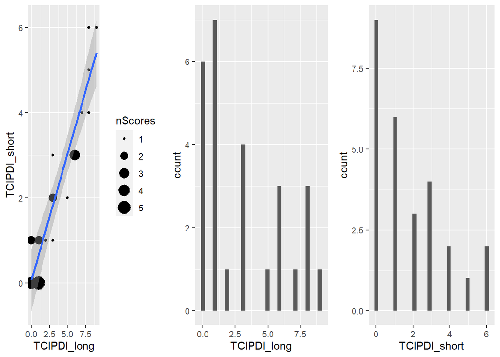

```r
D1S_PDI_TCI_summary <- D1S_PDI_TCI %>%
  group_by(TCIPDI_short, TCIPDI_long) %>%
  summarise(nScores = length(TCIPDI_long))

a <- ggplot(data=D1S_PDI_TCI_summary, aes(x=TCIPDI_long, y=TCIPDI_short)) +
  geom_point(aes(size=nScores)) + geom_smooth(method="lm")
b <- ggplot(data=D1S_PDI_TCI, aes(x=TCIPDI_long)) + geom_histogram()
c <- ggplot(data=D1S_PDI_TCI, aes(x=TCIPDI_short)) + geom_histogram()
gridExtra::grid.arrange(a,b,c,ncol=3)
```

In conclusion, these two scales are significantly correlated with one another, with a Pearson’s R = 0.94

## ii. Correlation of the TCI-PDI with the PDI

Next, in order to assess the validity of the TCI-PDI scales, we compare scores on these scales with scores on the PDI questionnaire. This comparison is important as it determines which of the TCI-PDI scales we will use in the rest of the studies in this paper.

```r
tcipdi_pdi <- D1S_PDI_TCI %>%
  select(SubjName, starts_with('TCIPDI'), PDI) %>%
  gather(TCIPDIversion, Score, -SubjName, -PDI) %>%
  group_by(TCIPDIversion) %>%
  summarise(R = cor(PDI, Score))
pandoc.table(tcipdi_pdi)
```

| TCIPDIversion | R |
| --- | --- |
| TCIPDI_long | 0.4648 |
| TCIPDI_short | 0.6393 |

Using only the questionnaires completed by participants who also completed PET, the correlations are as follows:

```r
tcipdi_pdi <- D1S_PDI_TCI %>%
  filter(!is.na(bp)) %>%
  select(SubjName, starts_with('TCIPDI'), PDI) %>%
  gather(TCIPDIversion, Score, -SubjName, -PDI) %>%
  group_by(TCIPDIversion) %>%
  summarise(R = cor(PDI, Score))
pandoc.table(tcipdi_pdi)
```

```
##
## ------------------------
##  TCIPDIversion     R
## --------------- --------
##   TCIPDI_long    0.3915
##
##  TCIPDI_short    0.6899
## ------------------------
```

Below I show the relationships between the plots. Due to both scales being discrete, the third plot on the right is the same as the second, but with slightly jittered points.

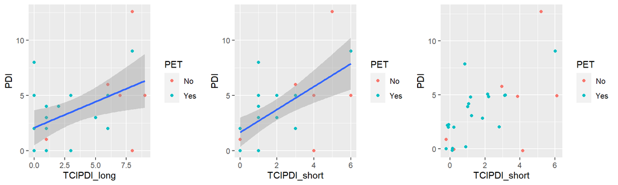

```r
D1S_PDI_TCI <- D1S_PDI_TCI %>%
  mutate(PET = ifelse(is.na(bp), 'No', 'Yes'))

a <- ggplot(data=D1S_PDI_TCI, aes(x=TCIPDI_long, y=PDI)) +
  geom_point(aes(colour=PET)) +
  geom_smooth(method="lm")
b <- ggplot(data=D1S_PDI_TCI, aes(x=TCIPDI_short, y=PDI)) +
  geom_point(aes(colour=PET)) +
  geom_smooth(method="lm")
c <- ggplot(data=D1S_PDI_TCI, aes(x=TCIPDI_short, y=PDI)) +
  geom_jitter(width=0.25, height=0.25, aes(colour=PET))
gridExtra::grid.arrange(a,b,c,ncol=3)
```

As we can see here, the short version of the TCI-PDI scale is more closely associated with PDI scores in this data set. We will therefore make use of the TCIPDI_short scale for the remainder of this study.

In order to estimate predicted PDI scores from one scale to the other, I fit a linear regression model:

```r
tcipdi_parameters <- D1S_PDI_TCI %>%
  do(tidy(lm(PDI ~ TCIPDI_short, data=.)))
kable(tcipdi_parameters, digits = c(2,2,2,2,4))
```

| term | estimate | std.error | statistic | p.value |
| --- | --- | --- | --- | --- |
| (Intercept) | 1.66 | 0.65 | 2.56 | 0.0170 |
| TCIPDI_short | 1.04 | 0.25 | 4.16 | 0.0003 |

# Substudy 1C: Relationship of TCI-PDI Questionnaire with D1 Receptor binding

```r
tcipdi_dadb_d1 <- alldata %>%
  filter(Study=='DADB', !is.na(TCIPDI_long), !is.na(bp))
```

We assessed whether there was a relationship between our newly developed TCI-PDI questionnaire and D1 receptor binding in an exploratory pilot study. Our primary region of interest was the dorsolateral prefrontal cortex as this region has frequently been found to be associated with psychosis and traits associated with proneness to develop psychosis. We also included the striatum as a highly reliable region to test for specificity.

In the database, there are 24 individuals who completed the TCI questionnaire at the time of their PET measurement. The database consists mostly of men, and mostly of young men (i.e. aged 20-35). The demographics of our sample were as follows:

```r
tcipdi_dadb_d1 <- tcipdi_dadb_d1 %>%
  mutate(oldyoung=ifelse(Age < 40, 'young', 'old'))


tcipdi_dadb_d1_dlpfc <- tcipdi_dadb_d1 %>%
  filter(Region=='DLPFC_46')

pandoc.table(table(tcipdi_dadb_d1_dlpfc$Sex, tcipdi_dadb_d1_dlpfc$oldyoung))
```

|  | old | young |
| --- | --- | --- |
| **female** | 2 | 6 |
| **male** | 3 | 13 |

```r
pandoc.table(psych::describe(tcipdi_dadb_d1_dlpfc$Age), split.table=Inf)
```

|  | vars | n | mean | sd | median | trimmed | mad | min | max | range | skew | kurtosis | se |
| --- | --- | --- | --- | --- | --- | --- | --- | --- | --- | --- | --- | --- | --- |
| **X1** | 1 | 24 | 35.02101 | 19.20227 | 25.73767 | 32.26804 | 2.838773 | 22.87717 | 76.47808 | 53.60091 | 1.338116 | -0.143237 | 3.919647 |

```r
tcipdi_dadb_d1_dlpfc_answers <- tcipdi_dadb_d1_dlpfc %>%
  select(one_of(paste0('TCI', tcipdiShort_items)))

(pdi_d1s_reliability <- alpha(tcipdi_dadb_d1_dlpfc_answers))
```

```
##
## Reliability analysis
## Call: alpha(x = tcipdi_dadb_d1_dlpfc_answers)
##
##   raw_alpha std.alpha G6(smc) average_r S/N  ase mean   sd median_r
##       0.65      0.66    0.82      0.19 1.9 0.11 0.29 0.24     0.17
##
##  lower alpha upper     95% confidence boundaries
## 0.45 0.65 0.86
##
##  Reliability if an item is dropped:
##        raw_alpha std.alpha G6(smc) average_r S/N alpha se var.r med.r
## TCI056      0.66      0.68    0.84      0.23 2.1    0.103 0.094 0.204
## TCI076      0.67      0.67    0.82      0.23 2.1    0.100 0.093 0.258
## TCI077      0.71      0.69    0.84      0.24 2.3    0.088 0.091 0.258
## TCI097      0.51      0.52    0.69      0.13 1.1    0.152 0.063 0.130
## TCI116      0.59      0.59    0.75      0.17 1.4    0.128 0.072 0.146
## TCI175      0.61      0.63    0.78      0.19 1.7    0.120 0.087 0.130
## TCI200      0.64      0.64    0.79      0.21 1.8    0.114 0.079 0.146
## TCI208      0.53      0.54    0.73      0.15 1.2    0.146 0.071 0.059
##
##  Item statistics
##         n raw.r std.r r.cor r.drop  mean   sd
## TCI056 24  0.35  0.36  0.20  0.156 0.167 0.38
## TCI076 24  0.41  0.38  0.28  0.169 0.333 0.48
## TCI077 24  0.30  0.30  0.15  0.039 0.458 0.51
## TCI097 24  0.83  0.84  0.90  0.734 0.250 0.44
## TCI116 24  0.66  0.65  0.65  0.462 0.458 0.51
## TCI175 24  0.58  0.55  0.51  0.389 0.250 0.44
## TCI200 24  0.43  0.49  0.44  0.304 0.083 0.28
## TCI208 24  0.78  0.78  0.82  0.649 0.292 0.46
##
## Non missing response frequency for each item
##           0    1 miss
## TCI056 0.83 0.17    0
## TCI076 0.67 0.33    0
## TCI077 0.54 0.46    0
## TCI097 0.75 0.25    0
## TCI116 0.54 0.46    0
## TCI175 0.75 0.25    0
## TCI200 0.92 0.08    0
## TCI208 0.71 0.29    0
```

```r
(pdi_d1s_reliability_long <- tcipdi_dadb_d1_dlpfc %>%
  select(one_of(paste0('TCI', tcipdiLong_items))) %>%
  alpha())
```

```
## Some items ( TCI051 TCI077 TCI220 ) were negatively correlated with the total scale and
## probably should be reversed.
## To do this, run the function again with the 'check.keys=TRUE' option
```

```
##
## Reliability analysis
## Call: alpha(x = .)
##
##   raw_alpha std.alpha G6(smc) average_r S/N ase mean   sd median_r
##       0.64      0.67    0.89      0.13   2 0.1 0.32 0.19     0.11
##
##  lower alpha upper     95% confidence boundaries
## 0.43 0.64 0.84
##
##  Reliability if an item is dropped:
##        raw_alpha std.alpha G6(smc) average_r S/N alpha se var.r med.r
## TCI006      0.61      0.64    0.84      0.13 1.8    0.117 0.079 0.120
## TCI038      0.60      0.63    0.85      0.12 1.7    0.120 0.080 0.087
## TCI051      0.66      0.69    0.90      0.16 2.2    0.097 0.087 0.148
## TCI056      0.63      0.66    0.88      0.14 1.9    0.107 0.093 0.120
## TCI076      0.64      0.67    0.88      0.14 2.0    0.103 0.092 0.128
## TCI077      0.68      0.69    0.87      0.16 2.2    0.094 0.087 0.163
## TCI097      0.55      0.58    0.82      0.10 1.4    0.135 0.071 0.087
## TCI116      0.57      0.61    0.85      0.12 1.6    0.127 0.072 0.102
## TCI175      0.57      0.62    0.85      0.12 1.6    0.125 0.084 0.068
## TCI194      0.61      0.62    0.86      0.12 1.6    0.115 0.088 0.087
## TCI200      0.62      0.65    0.87      0.13 1.8    0.111 0.084 0.109
## TCI208      0.56      0.60    0.85      0.11 1.5    0.129 0.074 0.068
## TCI220      0.72      0.73    0.90      0.18 2.7    0.082 0.072 0.174
##
##  Item statistics
##         n raw.r std.r  r.cor r.drop  mean   sd
## TCI006 24  0.52  0.49  0.488  0.355 0.417 0.50
## TCI038 24  0.57  0.55  0.541  0.407 0.542 0.51
## TCI051 24  0.19  0.17  0.075  0.020 0.250 0.44
## TCI056 24  0.38  0.39  0.328  0.237 0.167 0.38
## TCI076 24  0.34  0.33  0.274  0.162 0.333 0.48
## TCI077 24  0.17  0.18  0.135 -0.027 0.458 0.51
## TCI097 24  0.78  0.79  0.825  0.691 0.250 0.44
## TCI116 24  0.65  0.64  0.645  0.505 0.458 0.51
## TCI175 24  0.66  0.62  0.618  0.543 0.250 0.44
## TCI194 24  0.53  0.59  0.565  0.440 0.083 0.28
## TCI200 24  0.41  0.46  0.445  0.306 0.083 0.28
## TCI208 24  0.70  0.71  0.725  0.582 0.292 0.46
## TCI220 24 -0.11 -0.10 -0.186 -0.300 0.583 0.50
##
## Non missing response frequency for each item
##           0    1 miss
## TCI006 0.58 0.42    0
## TCI038 0.46 0.54    0
## TCI051 0.75 0.25    0
## TCI056 0.83 0.17    0
## TCI076 0.67 0.33    0
## TCI077 0.54 0.46    0
## TCI097 0.75 0.25    0
## TCI116 0.54 0.46    0
## TCI175 0.75 0.25    0
## TCI194 0.92 0.08    0
## TCI200 0.92 0.08    0
## TCI208 0.71 0.29    0
## TCI220 0.42 0.58    0
```

1. Including everyone, and correcting for Age and Sex
2. Excluding women, and correcting for Age
3. Excluding older individuals, and correcting for Gender
4. Excluding women and old men, and no correction

```r
everyone_models_s <- tcipdi_dadb_d1 %>%
  group_by(Region) %>%
  mutate(bp.z = scale(bp),  TCIPDI_short.z = scale(TCIPDI_short)) %>%
  do(tidy(lm(bp.z ~ TCIPDI_short.z + Sex, data=.))) %>%
  arrange(term, Region) %>%
  filter(term=='TCIPDI_short.z')
kable(everyone_models_s, digits = c(1,1,4,4,2,3))
```

| Region | term | estimate | std.error | statistic | p.value |
| --- | --- | --- | --- | --- | --- |
| DLPFC_46 | TCIPDI_short.z | -0.4884 | 0.1985 | -2.46 | 0.023 |
| gmfslSTR | TCIPDI_short.z | -0.5917 | 0.1900 | -3.11 | 0.005 |

```r
everyone_models_l <- tcipdi_dadb_d1 %>%
  group_by(Region) %>%
  mutate(bp.z = scale(bp), TCIPDI_long.z = scale(TCIPDI_long)) %>%
  do(tidy(lm(bp.z ~ TCIPDI_long.z + Age + Sex, data=.))) %>%
  arrange(term, Region) %>%
  filter(term=='TCIPDI_long.z')
kable(everyone_models_l, digits = c(1,1,4,4,2,3))
```

| Region | term | estimate | std.error | statistic | p.value |
| --- | --- | --- | --- | --- | --- |
| DLPFC_46 | TCIPDI_long.z | -0.2455 | 0.1525 | -1.61 | 0.123 |
| gmfslSTR | TCIPDI_long.z | -0.4738 | 0.1524 | -3.11 | 0.006 |

## *2. Excluding women, and correcting for Age*

```r
male_models_s <- tcipdi_dadb_d1 %>%
  filter(Sex == 'male') %>%
  group_by(Region) %>%
  mutate(bp.z = scale(bp),  TCIPDI_short.z = scale(TCIPDI_short)) %>%
  do(tidy(lm(bp.z ~ TCIPDI_short.z + Age, data=.))) %>%
  arrange(term, Region) %>%
  filter(term=='TCIPDI_short.z')
kable(male_models_s, digits = c(1,1,4,4,2,3))
```

| Region | term | estimate | std.error | statistic | p.value |
| --- | --- | --- | --- | --- | --- |
| DLPFC_46 | TCIPDI_short.z | -0.4541 | 0.1780 | -2.55 | 0.024 |
| gmfslSTR | TCIPDI_short.z | -0.5662 | 0.1704 | -3.32 | 0.005 |

```r
male_models_l <- tcipdi_dadb_d1 %>%
  filter(Sex == 'male') %>%
  group_by(Region) %>%
  mutate(bp.z = scale(bp), TCIPDI_long.z = scale(TCIPDI_long)) %>%
  do(tidy(lm(bp.z ~ TCIPDI_long.z + Age, data=.))) %>%
  arrange(term, Region) %>%
  filter(term=='TCIPDI_long.z')
kable(male_models_l, digits = c(1,1,4,4,2,3))
```

| Region | term | estimate | std.error | statistic | p.value |
| --- | --- | --- | --- | --- | --- |
| DLPFC_46 | TCIPDI_long.z | -0.3983 | 0.1875 | -2.12 | 0.053 |
| gmfslSTR | TCIPDI_long.z | -0.6088 | 0.1581 | -3.85 | 0.002 |

## *3. Excluding old, and correcting for Gender*

```r
young_models_s <- tcipdi_dadb_d1 %>%
  filter(Age >= 20 & Age <=35) %>%
  group_by(Region) %>%
  mutate(bp.z = scale(bp),  TCIPDI_short.z = scale(TCIPDI_short)) %>%
  do(tidy(lm(bp.z ~ TCIPDI_short.z + Sex, data=.))) %>%
  arrange(term, Region) %>%
  filter(term=='TCIPDI_short.z')
kable(young_models_s, digits = c(1,1,4,4,2,3))
```

| Region | term | estimate | std.error | statistic | p.value |
| --- | --- | --- | --- | --- | --- |
| DLPFC_46 | TCIPDI_short.z | -0.370 | 0.2138 | -1.73 | 0.103 |
| gmfslSTR | TCIPDI_short.z | -0.504 | 0.2149 | -2.35 | 0.032 |

```r
young_models_l <- tcipdi_dadb_d1 %>%
  filter(Age >= 20 & Age <=35) %>%
  group_by(Region) %>%
  mutate(bp.z = scale(bp), TCIPDI_long.z = scale(TCIPDI_long)) %>%
  do(tidy(lm(bp.z ~ TCIPDI_long.z + Sex, data=.))) %>%
  arrange(term, Region) %>%
  filter(term=='TCIPDI_long.z')
kable(young_models_l, digits = c(1,1,4,4,2,3))
```

| Region | term | estimate | std.error | statistic | p.value |
| --- | --- | --- | --- | --- | --- |
| DLPFC_46 | TCIPDI_long.z | -0.3353 | 0.2177 | -1.54 | 0.143 |
| gmfslSTR | TCIPDI_long.z | -0.5895 | 0.2013 | -2.93 | 0.010 |

## *4. Excluding women and old men, and no correction*

```r
youngmale_models_s <- tcipdi_dadb_d1 %>%
  filter(Sex == 'male') %>%
  filter(Age >= 20 & Age <=35) %>%
  group_by(Region) %>%
  mutate(bp.z = scale(bp),  TCIPDI_short.z = scale(TCIPDI_short)) %>%
  do(tidy(lm(bp.z ~ TCIPDI_short.z, data=.))) %>%
  arrange(term, Region) %>%
  filter(term=='TCIPDI_short.z')
kable(youngmale_models_s, digits = c(1,1,4,4,2,3))
```

| Region | term | estimate | std.error | statistic | p.value |
| --- | --- | --- | --- | --- | --- |
| DLPFC_46 | TCIPDI_short.z | -0.5915 | 0.2431 | -2.43 | 0.033 |
| gmfslSTR | TCIPDI_short.z | -0.6817 | 0.2206 | -3.09 | 0.010 |

```r
youngmale_models_l <- tcipdi_dadb_d1 %>%
  filter(Sex == 'male') %>%
  filter(Age >= 20 & Age <=35) %>%
  group_by(Region) %>%
  mutate(bp.z = scale(bp), TCIPDI_long.z = scale(TCIPDI_long)) %>%
  do(tidy(lm(bp.z ~ TCIPDI_long.z, data=.))) %>%
  arrange(term, Region) %>%
  filter(term=='TCIPDI_long.z')

kable(youngmale_models_l, digits = c(1,1,4,4,2,3))
```

| Region | term | estimate | std.error | statistic | p.value |
| --- | --- | --- | --- | --- | --- |
| DLPFC_46 | TCIPDI_long.z | -0.5674 | 0.2483 | -2.29 | 0.043 |
| gmfslSTR | TCIPDI_long.z | -0.7767 | 0.1899 | -4.09 | 0.002 |

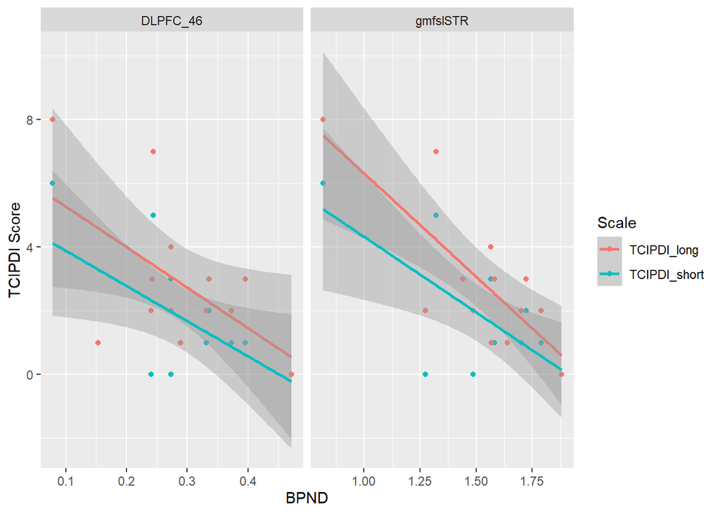

```r
tcipdi_dadb_d1 %>%
  filter(Sex == 'male') %>%
  filter(Age >= 20 & Age <=35) %>%
  gather(Scale,Score,TCIPDI_short, TCIPDI_long) %>%
  ggplot(., aes(y=Score, x=bp, colour=Scale)) +
  geom_point() + geom_smooth(method="lm") +
  xlab('BPND') + ylab('TCIPDI Score') +
  facet_grid(~ Region, scales = 'free_x')
```

Thus we can conclude that both scales appear to be correlated with D1 BP<sub>ND</sub> in both the dorsolateral prefrontal cortex and in the striatum, according to our pilot exploratory analysis. This result appears to be strongest for the young males, who are best represented by the PET database. However, we need to confirm this result in a future sample to be sure that it is truly representative.

Below are the unstandardised estimates:

```r
tcipdi_d1_parameters <- tcipdi_dadb_d1 %>%
  filter(Sex == 'male') %>%
  filter(Age >= 20 & Age <=35) %>%
  group_by(Region) %>%
  do(tidy(lm(bp ~ TCIPDI_short, data=.))) %>%
  arrange(Region, term)
kable(tcipdi_d1_parameters, digits = c(1,1,4,4,2,3))
```

| Region | term | estimate | std.error | statistic | p.value |
| --- | --- | --- | --- | --- | --- |
| DLPFC_46 | (Intercept) | 0.3431 | 0.0339 | 10.13 | 0.000 |
| DLPFC_46 | TCIPDI_short | -0.0317 | 0.0130 | -2.43 | 0.033 |
| gmfslSTR | (Intercept) | 1.7032 | 0.0825 | 20.65 | 0.000 |
| gmfslSTR | TCIPDI_short | -0.0980 | 0.0317 | -3.09 | 0.010 |

## Table for Publication

```r
library(kableExtra)

allmodels <- bind_rows(all_l = everyone_models_l, all_s = everyone_models_s,
                       male_l = male_models_l, male_s = male_models_s,
                       young_l = young_models_l, young_s = young_models_s,
                       youngmale_l = youngmale_models_l, youngmale_s = youngmale_models_s,
                       .id = 'id') %>%
  ungroup() %>%
  mutate(Gender = ifelse(grepl('male', .$id), 'Exclusion', 'Covariate'),
         Age    = ifelse(grepl('young', .$id), 'Exclusion', 'Covariate')) %>%
  mutate(Region = ifelse(Region=='DLPFC_46', 'DLPFC', 'Striatum'),
         term = ifelse(term=='TCIPDI_long.z', 'Long', 'Short')) %>%
  mutate(nsample = 24) %>%
  mutate(nsample = ifelse(Gender=='Exclusion', nsample-8, nsample)) %>%
  mutate(nsample = ifelse(Age=='Exclusion', nsample-4, nsample)) %>%
  mutate(nsample = ifelse(Age=='Exclusion' & Gender=='Exclusion', 13, nsample)) %>%
  select(Region, 'TCI-DI Scale'=term,Gender,Age, n=nsample,
         "beta.std"=estimate, 'P Value' = p.value) %>%
  mutate_if(is.numeric, funs(round(.,3))) %>%
  arrange(Region, -n) %>%
  select(-Region)


kable(allmodels, format='latex', caption = 'Associations between TCI-DI scores and binding potential',
      booktabs=T, linesep = c("", "", "", "\\addlinespace")) %>%
  group_rows('DLPFC', 1,8) %>%
  group_rows('Striatum', 9,16)
```

## Figure for summary

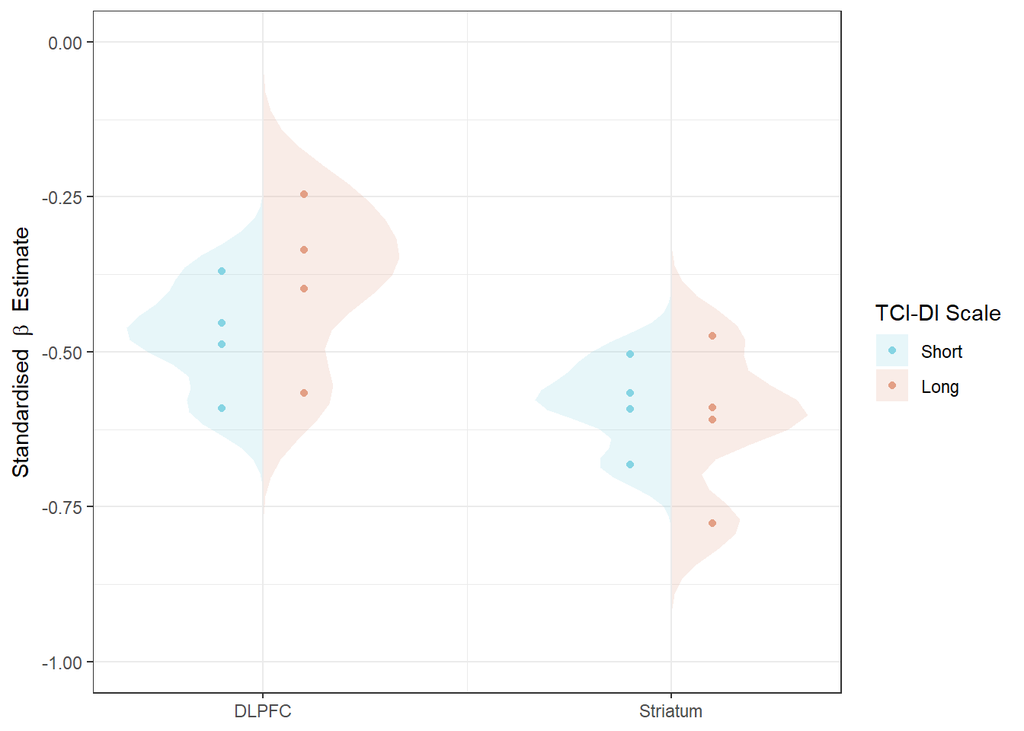

```r
# beta_fig_data <- allmodels %>%
#   mutate(Region = c(rep('DLPFC', 8), rep('Striatum', 8))) %>%
#   mutate(Nudge = ifelse(Region=='DLPFC', -0.1, 0.1)) %>%
#   arrange(desc(`TCI-DI Scale`)) %>%
#   mutate(`TCI-DI Scale` = forcats::fct_inorder(`TCI-DI Scale`))
#
# beta_fig <- ggplot(beta_fig_data, aes(y=beta.std, x=`TCI-DI Scale`, colour=`TCI-DI Scale`)) +
#   geom_violin(aes(fill=`TCI-DI Scale`),
#               alpha=0.2) +
#   ylim(c(-1, 0)) +
#   geom_point(position=position_nudge(x=beta_fig_data$Nudge), aes(shape=Region)) +
#   theme_bw() +
#   labs(y=expression('Standardised '~beta ~ ' Estimate')) +
#   scale_colour_manual(guide=FALSE, values = c("#85d4e3", "#e39f85")) +
#   scale_fill_manual(guide=FALSE, values = c("#85d4e3", "#e39f85"))
#
# beta_fig_data <- allmodels %>%
#   mutate(Region = c(rep('DLPFC', 8), rep('Striatum', 8))) %>%
#   mutate(Nudge = ifelse(`TCI-DI Scale`=='Short', -0.1, 0.1)) %>%
#   arrange(desc(`TCI-DI Scale`)) %>%
#   mutate(`TCI-DI Scale` = forcats::fct_inorder(`TCI-DI Scale`))
#
# beta_fig <- ggplot(beta_fig_data, aes(y=beta.std, x=Region, colour=Region)) +
#   geom_violin(aes(fill=Region),
#               alpha=0.2,
#               draw_quantiles = c(0.5)) +
#   ylim(c(-1, 0)) +
#   geom_point(position=position_nudge(x=beta_fig_data$Nudge), aes(shape=`TCI-DI Scale`)) +
#   theme_bw() +
#   labs(y=expression('Standardised '~beta ~ ' Estimate')) +
#   scale_colour_manual(guide=FALSE, values = c("#85d4e3", "#e39f85")) +
#   scale_fill_manual(guide=FALSE, values = c("#85d4e3", "#e39f85"))



beta_fig_data <- allmodels %>%
  mutate(Region = c(rep('DLPFC', 8), rep('Striatum', 8))) %>%
  mutate(Nudge = ifelse(`TCI-DI Scale`=='Short', -0.1, 0.1)) %>%
  arrange(desc(`TCI-DI Scale`)) %>%
  mutate(`TCI-DI Scale` = forcats::fct_inorder(`TCI-DI Scale`)) %>%
  mutate(xpos = ifelse(Region=='DLPFC', 0, 1)) %>%
  mutate(xpos = xpos + ifelse(`TCI-DI Scale` == 'Short', -0.1, 0.1))

dens_n <- 25

beta_fig_densdata <- allmodels %>%
  mutate(Region = c(rep('DLPFC', 8), rep('Striatum', 8))) %>%
  mutate(Nudge = ifelse(`TCI-DI Scale`=='Short', -0.1, 0.1)) %>%
  arrange(desc(`TCI-DI Scale`)) %>%
  mutate(`TCI-DI Scale` = forcats::fct_inorder(`TCI-DI Scale`)) %>%
  group_by(Region, `TCI-DI Scale`) %>%
  do(data.frame(loc = density(.$beta.std, n=dens_n)$x,
                dens = density(.$beta.std, n=dens_n)$y)) %>%
  mutate(dens = dens/(3*max(dens)))

beta_fig_densdata$dens <- ifelse(beta_fig_densdata$`TCI-DI Scale` == 'Short',
                             beta_fig_densdata$dens * -1, beta_fig_densdata$dens)
beta_fig_densdata$dens <- ifelse(beta_fig_densdata$Region == 'Striatum',
                             beta_fig_densdata$dens + 1, beta_fig_densdata$dens)


beta_fig <- ggplot(beta_fig_densdata, aes(dens, loc, fill=`TCI-DI Scale`,
                                      group = interaction(`TCI-DI Scale`, Region))) +
  geom_polygon(alpha=0.2) +
  scale_x_continuous('Region', breaks = 0:1, labels = c('DLPFC', 'Striatum')) +
  ylab(expression('Standardised '~beta ~ ' Estimate')) +
  theme_bw() +
  theme(axis.title.x = element_blank()) +
  ylim(c(-1, 0)) +
  geom_point(data=beta_fig_data,
             #position=position_nudge(x=beta_fig_data$Nudge),
             aes(y=beta.std, x=xpos, colour=`TCI-DI Scale`)) +
  scale_colour_manual(values = c("#85d4e3", "#e39f85")) +
  scale_fill_manual(values = c("#85d4e3", "#e39f85"))


print(beta_fig)
```

```r
ggsave('../Figures/Beta_fig.jpg', beta_fig, width = 4, height=6)
```

## Summary Statistics

```r
DADB_summarygroup <- alldata %>%
  filter(Study=='DADB', !is.na(bp)) %>%
  filter(Region=='DLPFC_46', PETNo==1) %>%
  select(-starts_with('PDI'), -starts_with('TCI'))

DADB_summarygroup %>%
  select_if(is.numeric) %>%
  describe() %>%
  kable()
```

|  | vars | n | mean | sd | median | trimmed | mad | min | max | range | skew | kurtosis | se |
| --- | --- | --- | --- | --- | --- | --- | --- | --- | --- | --- | --- | --- | --- |
| PETNo | 1 | 56 | 1.0000000 | 0.0000000 | 1.0000000 | 1.0000000 | 0.0000000 | 1.0000000 | 1.0000000 | 0.0000000 | NaN | NaN | 0.0000000 |
| bp | 2 | 56 | 0.2807109 | 0.1016699 | 0.2944013 | 0.2838536 | 0.0790195 | 0.0452749 | 0.4712498 | 0.4259749 | -0.3597929 | -0.5758678 | 0.0135862 |
| Age | 3 | 56 | 29.2947366 | 13.5889547 | 25.1598174 | 25.6214810 | 2.4486595 | 20.6490868 | 76.4780822 | 55.8289954 | 2.6488685 | 5.5177322 | 1.8159005 |
| InjRadioactivity | 4 | 56 | 303.8750000 | 25.4423144 | 306.0000000 | 306.1304348 | 20.7564000 | 221.0000000 | 350.0000000 | 129.0000000 | -0.9513012 | 1.0605296 | 3.3998723 |
| Age_PDI | 5 | 41 | 32.9492997 | 3.2186197 | 33.1088296 | 32.8376994 | 2.0863967 | 25.4483231 | 43.9397673 | 18.4914442 | 0.5719087 | 2.0318273 | 0.5026639 |
| D1 | 6 | 41 | 1.0000000 | 0.0000000 | 1.0000000 | 1.0000000 | 0.0000000 | 1.0000000 | 1.0000000 | 0.0000000 | NaN | NaN | 0.0000000 |
| Age_PET | 7 | 41 | 25.0394142 | 2.9218345 | 24.6803653 | 24.7942853 | 2.3271404 | 20.6490868 | 35.2664384 | 14.6173516 | 1.0855250 | 2.0150681 | 0.4563139 |
| PET2PDI | 8 | 41 | 7.9098855 | 1.5634620 | 8.1202493 | 7.9787856 | 0.7466387 | 4.7474201 | 12.7050210 | 7.9576008 | -0.0005642 | 1.4155048 | 0.2441717 |
| FF_Kod | 9 | 41 | 5226.4146341 | 2257.9796276 | 4992.0000000 | 5106.6666667 | 2616.7890000 | 1501.0000000 | 9757.0000000 | 8256.0000000 | 0.4056342 | -0.7218794 | 352.6371727 |
| SpecAc | 10 | 0 | NaN | NA | NA | NaN | NA | Inf | -Inf | -Inf | NA | NA | NA |
| InjMass | 11 | 0 | NaN | NA | NA | NaN | NA | Inf | -Inf | -Inf | NA | NA | NA |

# Substudy 2: Replication of TCIPDI Finding

We can test the reliability of our original finding using the replication Bayes Factor. First, we evaluate the reliability of our measurements of TCIPDI scores, and then we assess how the degree of replication of the original findings.

## TCIPDI Reliability

To assess the reliability of the TCIPDI scale, we calculate Cronbach’s $\alpha$ for this set of scores:

```r
tcipdi_rawscores <- alldata %>%
  filter(Study=='D1S', !is.na(bp)) %>%
  filter(Region=='DLPFC_46', PETNo==1) %>%    # One response per subject
  select(one_of(paste0('TCI', tcipdiShort_items)))

(tcipdi_d1s_alpha <- alpha(tcipdi_rawscores))
```

```
## Some items ( TCI175 ) were negatively correlated with the total scale and
## probably should be reversed.
## To do this, run the function again with the 'check.keys=TRUE' option
```

```
##
## Reliability analysis
## Call: alpha(x = tcipdi_rawscores)
##
##   raw_alpha std.alpha G6(smc) average_r S/N  ase mean   sd median_r
##       0.61      0.65    0.81      0.19 1.8 0.13 0.17 0.19     0.18
##
##  lower alpha upper     95% confidence boundaries
## 0.35 0.61 0.87
##
##  Reliability if an item is dropped:
##        raw_alpha std.alpha G6(smc) average_r S/N alpha se var.r med.r
## TCI056      0.61      0.62    0.78      0.19 1.6     0.13 0.072  0.22
## TCI076      0.61      0.64    0.74      0.20 1.8     0.13 0.064  0.22
## TCI077      0.63      0.66    0.82      0.21 1.9     0.13 0.072  0.14
## TCI097      0.53      0.58    0.78      0.16 1.4     0.16 0.066  0.14
## TCI116      0.60      0.64    0.81      0.20 1.7     0.14 0.068  0.14
## TCI175      0.62      0.68    0.78      0.23 2.1     0.13 0.055  0.22
## TCI200      0.53      0.54    0.71      0.14 1.2     0.16 0.054  0.14
## TCI208      0.49      0.55    0.69      0.15 1.2     0.18 0.061  0.14
##
##  Item statistics
##         n raw.r std.r r.cor r.drop mean   sd
## TCI056 20  0.47  0.52  0.45   0.22 0.20 0.41
## TCI076 20  0.47  0.45  0.43   0.22 0.20 0.41
## TCI077 20  0.49  0.40  0.26   0.19 0.40 0.50
## TCI097 20  0.65  0.65  0.58   0.48 0.15 0.37
## TCI116 20  0.46  0.47  0.36   0.25 0.15 0.37
## TCI175 20  0.25  0.32  0.26   0.11 0.05 0.22
## TCI200 20  0.71  0.75  0.77   0.63 0.05 0.22
## TCI208 20  0.75  0.73  0.75   0.61 0.15 0.37
##
## Non missing response frequency for each item
##           0    1 miss
## TCI056 0.80 0.20    0
## TCI076 0.80 0.20    0
## TCI077 0.60 0.40    0
## TCI097 0.85 0.15    0
## TCI116 0.85 0.15    0
## TCI175 0.95 0.05    0
## TCI200 0.95 0.05    0
## TCI208 0.85 0.15    0
```

We observe a Cronbach’s $\alpha$ of 0.61, which is not particularly good, but probably useable. Hopefully, with extra participants this value will increase. This means that we can proceed with this study.

## Summary Statistics

```r
D1S_summarygroup <- alldata %>%
  filter(Study=='D1S', !is.na(bp)) %>%
  filter(Region=='DLPFC_46', PETNo==1) %>%
  select(-starts_with('PDI'), -starts_with('TCI'))

D1S_summarygroup %>%
  select_if(is.numeric) %>%
  describe() %>%
  kable()
```

|  | vars | n | mean | sd | median | trimmed | mad | min | max | range | skew | kurtosis | se |
| --- | --- | --- | --- | --- | --- | --- | --- | --- | --- | --- | --- | --- | --- |
| PETNo | 1 | 20 | 1.0000000 | 0.0000000 | 1.0000000 | 1.0000000 | 0.0000000 | 1.0000000 | 1.0000000 | 0.0000000 | NaN | NaN | 0.0000000 |
| bp | 2 | 20 | 0.3254798 | 0.0514461 | 0.3253767 | 0.3249467 | 0.0387669 | 0.2247905 | 0.4312079 | 0.2064174 | 0.0483012 | -0.2220964 | 0.0115037 |
| Age | 3 | 20 | 25.9073238 | 3.1984330 | 24.8829569 | 25.3863792 | 2.1980230 | 21.7796030 | 34.9596167 | 13.1800137 | 1.3147735 | 1.2280502 | 0.7151914 |
| InjRadioactivity | 4 | 20 | 336.1500000 | 46.2706853 | 331.0000000 | 335.1875000 | 57.0801000 | 248.0000000 | 417.0000000 | 169.0000000 | 0.0948492 | -1.1391520 | 10.3464398 |
| Age_PDI | 5 | 0 | NaN | NA | NA | NaN | NA | Inf | -Inf | -Inf | NA | NA | NA |
| D1 | 6 | 0 | NaN | NA | NA | NaN | NA | Inf | -Inf | -Inf | NA | NA | NA |
| Age_PET | 7 | 0 | NaN | NA | NA | NaN | NA | Inf | -Inf | -Inf | NA | NA | NA |
| PET2PDI | 8 | 0 | NaN | NA | NA | NaN | NA | Inf | -Inf | -Inf | NA | NA | NA |
| FF_Kod | 9 | 0 | NaN | NA | NA | NaN | NA | Inf | -Inf | -Inf | NA | NA | NA |
| SpecAc | 10 | 14 | 548.0714286 | 277.2495306 | 546.0000000 | 546.3333333 | 240.9225000 | 18.0000000 | 1099.0000000 | 1081.0000000 | 0.0376311 | -0.5548541 | 74.0980539 |
| InjMass | 11 | 20 | 0.5388990 | 1.3714962 | 0.2179905 | 0.2340783 | 0.1226799 | 0.0924353 | 6.3471478 | 6.2547125 | 3.7835356 | 13.0870998 | 0.3066759 |

## Replication Bayes Factor

Having observed a significant relationship between the TCIPDI scale and D1 Receptor BP<sub>ND</sub>, but no evidence for a relationship of this magnitude using the online PDI data, we sought to attempt to replicate this finding in a similar data set. For this we can use a replication Bayes Factor.

First, we can source the relevant command directly from the website of Josine Verhagen, who created the correlation replication Bayes Factor:

```r
source('http://www.josineverhagen.com/wp-content/uploads/2013/07/RepfunctionscorrelationFINAL1.txt')
```

The correlation Bayes Factor can be calculated directly from only the r values and the sample sizes of the two studies, since these values contain all the relevant information. Firstly, we need the r and sample size of the original study:

```r
youngmale_models <- tcipdi_dadb_d1 %>%
  filter(Sex == 'male') %>%
  filter(Age >= 20 & Age <=35) %>%
  group_by(Region) %>%
  mutate(bp.z = scale(bp),  TCIPDI_short.z = scale(TCIPDI_short)) %>%
  do(tidy(lm(bp.z ~ TCIPDI_short.z, data=.))) %>%
  arrange(term, Region) %>%
  filter(term=='TCIPDI_short.z')

youngmale_samples <- tcipdi_dadb_d1 %>%
  filter(Sex == 'male') %>%
  filter(Age >= 20 & Age <=35) %>%
  group_by(Region) %>%
  summarise(n_subj = length(bp))

# DLPFC
(tcipdi_original_n_dlpfc <- youngmale_samples$n_subj[1])
```

```
## [1] 13
```

```r
(tcipdi_original_r_dlpfc <- youngmale_models$estimate[1])
```

```
## [1] -0.5914989
```

```r
# STR
(tcipdi_original_n_str <- youngmale_samples$n_subj[2])
```

```
## [1] 13
```

```r
(tcipdi_original_r_str <- youngmale_models$estimate[2])
```

```
## [1] -0.681671
```

Now, we just need to calculate the same correlation strengths for the new data:

```r
pers_d1s_d1 <- alldata %>%
  filter(!is.na(bp), PETNo==1) %>%
  filter(Study=='D1S', !is.na(TCIPDI_short))

youngmale_d1s_models <- pers_d1s_d1 %>%
  filter(PETNo == 1) %>%
  group_by(Region) %>%
  mutate(bp.z = scale(bp),  TCIPDI_short.z = scale(TCIPDI_short)) %>%
  do(tidy(lm(bp.z ~ TCIPDI_short.z, data=.))) %>%
  arrange(term, Region) %>%
  filter(term=='TCIPDI_short.z')
kable(youngmale_d1s_models, digits = c(1,1,4,4,2,3))
```

| Region | term | estimate | std.error | statistic | p.value |
| --- | --- | --- | --- | --- | --- |
| DLPFC_46 | TCIPDI_short.z | 0.0469 | 0.2354 | 0.20 | 0.844 |
| gmfslSTR | TCIPDI_short.z | 0.0665 | 0.2352 | 0.28 | 0.781 |

```r
youngmale_d1s_samples <- pers_d1s_d1 %>%
  filter(PETNo == 1) %>%
  group_by(Region) %>%
  summarise(n_subj = length(bp))

# DLPFC
(tcipdi_rep_n_dlpfc <- youngmale_d1s_samples$n_subj[1])
```

```
## [1] 20
```

```r
(tcipdi_rep_r_dlpfc <- youngmale_d1s_models$estimate[1])
```

```
## [1] 0.04687635
```

```r
# STR
(tcipdi_rep_n_str <- youngmale_d1s_samples$n_subj[2])
```

```
## [1] 20
```

```r
(tcipdi_rep_r_str <- youngmale_d1s_models$estimate[2])
```

```
## [1] 0.06649782
```

We should also examine scatterplots of the relationships between these measures.

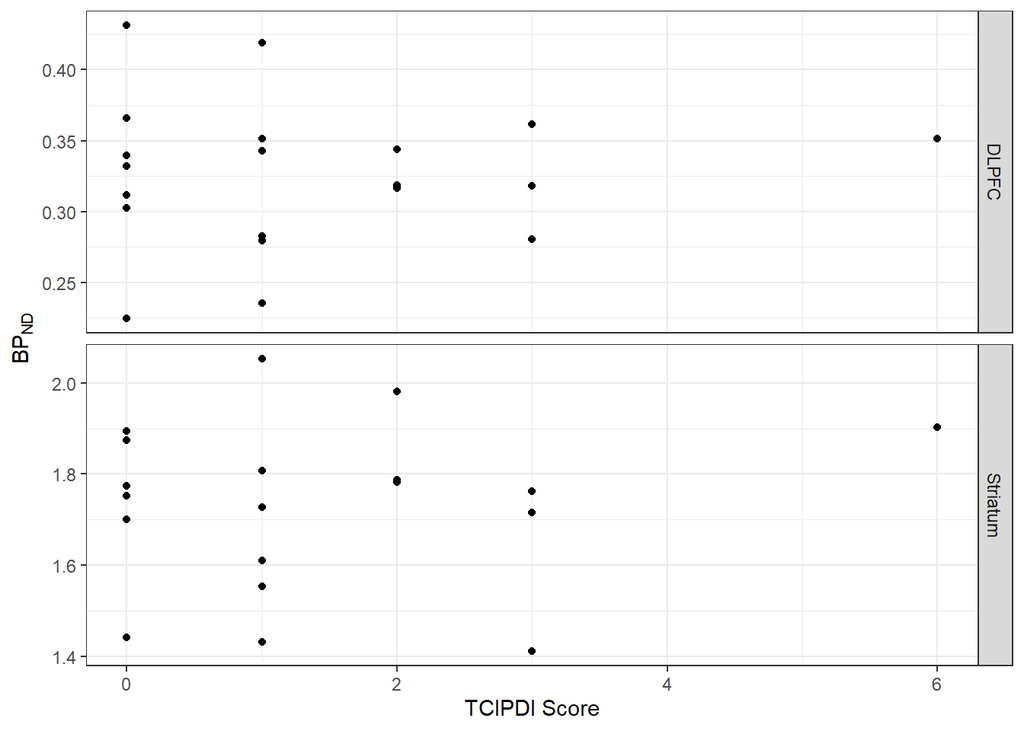

```r
youngmale_d1s_fig <- pers_d1s_d1 %>%
  filter(PETNo == 1) %>%
  mutate(Region = gsub('DLPFC_46', 'DLPFC', Region)) %>%
  mutate(Region = gsub('gmfslSTR', 'Striatum', Region)) %>%
  ggplot(aes(x=TCIPDI_short, y=bp)) +
  facet_grid(Region ~ ., scales="free_y") +
  geom_point() +
  labs(y=expression(BP[ND]),
       x='TCIPDI Score') +
  theme_bw()


print(youngmale_d1s_fig)
```

### Publication Scatterplots

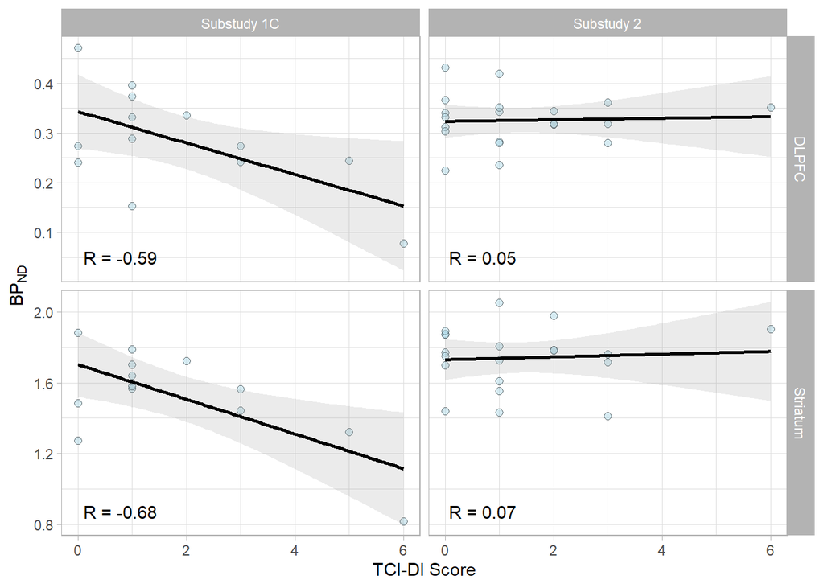

```r
tcipdi_study2 <- tcipdi_dadb_d1 %>%
  filter(Sex == 'male') %>%
  filter(Age >= 20 & Age <=35)

tcipdi_study5 <- pers_d1s_d1 %>%
  filter(PETNo == 1)

tcipdi_studies_data <- bind_rows(tcipdi_study2, tcipdi_study5) %>%
  mutate(Study = ifelse(Study=='DADB', 'Substudy 1C', 'Substudy 2')) %>%
  mutate(Region = gsub('DLPFC_46', 'DLPFC', Region)) %>%
  mutate(Region = gsub('gmfslSTR', 'Striatum', Region))

tdipdi_studies_correlations <- tcipdi_studies_data %>%
  group_by(Study, Region) %>%
  nest() %>%
  mutate(r = map_dbl(data, ~cor(.x$TCIPDI_short, .x$bp))) %>%
  select(-data) %>%
  mutate(label=paste0('R = ',round(r, 2))) #%>%
  # mutate(yspot=rep(c(0.9, 0.1), times=2))

tcipdi_studies <- ggplot(tcipdi_studies_data, aes(x=TCIPDI_short, y=bp)) +
  facet_grid(Region ~ Study, scales="free_y") +
  geom_point(shape = 21, colour = "black", fill="lightblue", size = 2, alpha=0.5) +
  labs(y=expression(BP[ND]),
       x='TCI-DI Score') +
  theme_light() +
  geom_smooth(method="lm", se=T, colour='black', alpha=0.2) +
  geom_text(data=tdipdi_studies_correlations,
            mapping=aes(x = -Inf, y = -Inf, label = label),
            hjust   = -0.3,
            vjust   = -1.3)

tcipdi_studies
```

```r
ggsave(tcipdi_studies, filename = '../Figures/Study4_scatters.jpg',
       width = 9, height=6, dpi=900)
```

Using this information, we can calculate and plot the replication Bayes Factor.

## DLPFC

```r
# Replication Bayes Factor: DLPFC
REPBF10_dlpfc <- CorrelationReplicationBF(tcipdi_original_r_dlpfc, tcipdi_original_n_dlpfc,
                                          tcipdi_rep_r_dlpfc, tcipdi_rep_n_dlpfc)
REPBF10_dlpfc
```

```
##      BF01      BF10
## 5.5254667 0.1809802
```

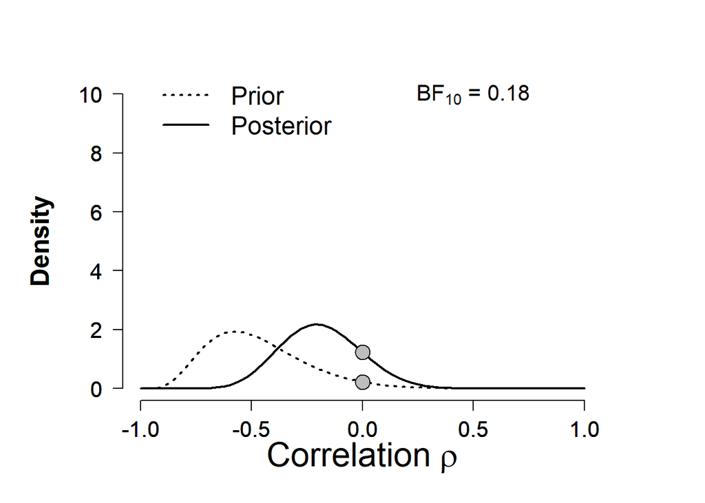

```r
dlpfc_repbfplot <- repposteriorplot(tcipdi_original_n_dlpfc, tcipdi_original_r_dlpfc,
                                    tcipdi_rep_n_dlpfc, tcipdi_rep_r_dlpfc)
```

As such, we find evidence to conclude that these findings were not replicated. The null hypothesis is 5.5 times more likely. This is, according to Jeffreys’ guidelines, moderate evidence in favour of the null hypothesis.

## Striatum

```r
REPBF10_str <- CorrelationReplicationBF(tcipdi_original_r_str, tcipdi_original_n_str,
                                        tcipdi_rep_r_str, tcipdi_rep_n_str)
REPBF10_str
```

```
##        BF01        BF10
## 10.48680209  0.09535795
```

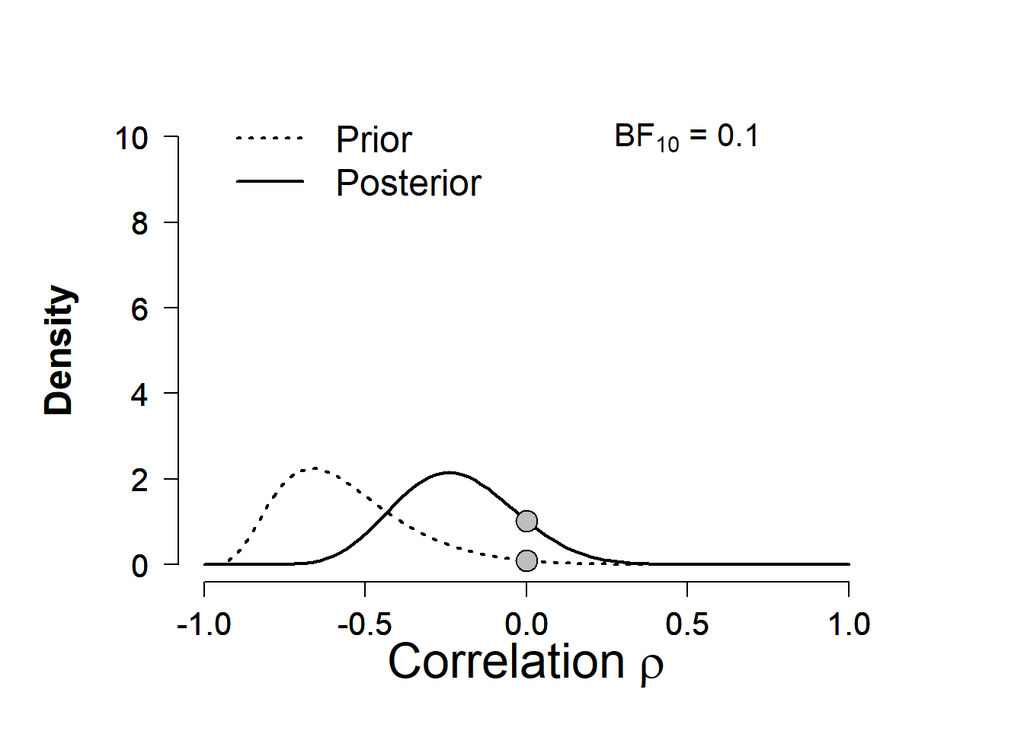

```r
str_repbfplot <- repposteriorplot(tcipdi_original_n_str, tcipdi_original_r_str,
                                  tcipdi_rep_n_str, tcipdi_rep_r_str)
```

# Prior Selection: Studies 3-4

In order to create priors for the future studies, we can use published literature as well as the values estimated above to come up with approximations. I will create priors both for the relationship of D1 receptor binding with age, as well as for the expected relationships between D1 receptor binding and scores on the PDI and the TCIPDI.

## Priors for the relationship of D1 Receptor BP<sub>ND</sub> with age

The relationship of D1 receptor BP<sub>ND</sub> using \[^11^C]SCH-23390 and age has been reported on several times in the past. For the sake of time and of not including the oldest PET studies which are most prone to partial volume effects due to low resolution, we will focus on studies published within the last 20 years.

### DLPFC Decreases:

```r
maxage <- 35
minage <- 20
midage <- mean(c(maxage, minage))
elapsed_years <- maxage-minage

jucaite_dlpfc_max <- 0.62*exp((-0.03)*minage)
jucaite_dlpfc_min <- 0.62*exp((-0.03)*maxage)
jucaite_dlpfc_mid <- 0.62*exp((-0.03)*midage)
(jucaite_dlpfc_change <- 10*( ((jucaite_dlpfc_max-jucaite_dlpfc_min)/0.42) / elapsed_years) )  # 0.42 is the mean
```

```
## [1] 0.1957172
```

```r
dlpfcdecadevals <- c(-0.08, -0.155, -0.24, -0.122)
dlpfcyearvals <- dlpfcdecadevals/10
kable(psych::describe(dlpfcyearvals), digits = 3)
```

|  | vars | n | mean | sd | median | trimmed | mad | min | max | range | skew | kurtosis | se |
| --- | --- | --- | --- | --- | --- | --- | --- | --- | --- | --- | --- | --- | --- |
| X1 | 1 | 4 | -0.015 | 0.007 | -0.014 | -0.015 | 0.006 | -0.024 | -0.008 | 0.016 | -0.316 | -1.921 | 0.003 |

```r
age_n <- c(19, 30, 40, 56)
(dlpfc_age_weightedmean <- Hmisc::wtd.mean(dlpfcyearvals, age_n))
```

```
## [1] -0.01558759
```

```r
(dlpfc_age_weightedsd <- sqrt(Hmisc::wtd.var(dlpfcyearvals, age_n)))
```

```
## [1] 0.005631926
```

Thus, we estimate that the yearly decrease for the DLPFC is of -1.6 % $\pm$ 0.6 %. These will be saved for later for use in the models.

```r
dlpfc_age_mean = dlpfc_age_weightedmean
dlpfc_age_sd = dlpfc_age_weightedsd
```

### Striatal Decreases:

```r
maxage <- 35
minage <- 20
elapsed_years <- maxage-minage

jucaite_str_max <- 1.90*exp((-0.009)*minage)
jucaite_str_min <- 1.90*exp((-0.009)*maxage)
(jucaite_str_change <- 10*( ((jucaite_str_max-jucaite_str_min)/jucaite_str_max) / elapsed_years) )
```

```
## [1] 0.08418939
```

```r
strdecadevals <- c(-0.069 , -0.077 , -0.08, -0.074)
stryearvals <- strdecadevals/10
kable(psych::describe(stryearvals), digits = 3)
```

|  | vars | n | mean | sd | median | trimmed | mad | min | max | range | skew | kurtosis | se |
| --- | --- | --- | --- | --- | --- | --- | --- | --- | --- | --- | --- | --- | --- |
| X1 | 1 | 4 | -0.008 | 0 | -0.008 | -0.008 | 0 | -0.008 | -0.007 | 0.001 | 0.204 | -1.999 | 0 |

```r
(str_age_weightedmean <- Hmisc::wtd.mean(stryearvals, age_n))
```

```
## [1] -0.007562069
```

```r
(str_age_weightedsd <- sqrt(Hmisc::wtd.var(stryearvals, age_n)))
```

```
## [1] 0.0003539595
```

Thus, we estimate that the yearly decrease for the striatum is of -0.8 % $\pm$ 0.04 %. These will be saved for later for use in the models.

```r
str_age_mean = str_age_weightedmean
str_age_sd = str_age_weightedsd
```

## Priors for the relationship of D1 Receptor BP<sub>ND</sub> with measures of psychosis proneness

This is a slightly more precarious prior to create, as this relationship has not been probed before. There have, however, been investigations of changes of the availability of D1 receptor binding in healthy controls and in schizophrenia patients, and the PDI has also been tested both in healthy controls and in delusional patients. We can use this information to come up with priors for potential effect sizes. On the other hand, though, there have been different results regarding the change in D1 Receptor BP<sub>ND</sub> in schizophrenia.

### Literature Priors

Although the relationship between D1 receptor binding assessed using PET has not been related to scores in the Peters Delusional Inventory before, we can still use the literature to derive suitable priors for this association, since there have been PET studies assessing differences between patients and controls in D1 receptor binding, and Peters compared scores on the PDI for healthy control patients and for delusional patients.

In Peters (2004), healthy control subjects were found to have a mean PDI score of 6, while delusional patients had a mean PDI score of 11. Thus, assuming that schizophrenia patients have similar PDI scores to the delusional patients, we can assume that an increase of 5 points on the PDI scale reflects the average difference in PDI scores between healthy control subjects and patients with schizophrenia.

There is some debate in the literature regarding the changes observed in PET D1 receptor binding in schizophrenia. The Chiba group in Japan has found decreases in schizophrenia patients compared to healthy controls in two studies, and using two ligands. The Columbia group in the USA has found increases in patients compared to healthy controls in two studies, using the same two ligands. The Turku group in Finland also found higher D1 receptor BP<sub>ND</sub> using [11C]SCH-23390 in individuals at high genetic risk for schizophrenia, however they also found that schizophrenia patients showed reductions in D1 receptor BP<sub>ND</sub> compared to healthy controls.

As such, there are a number of potential explanatory factors:

- Antipsychotic use (likely important)
- Radioligand (likely unimportant, though [11C]NNC112 has higher BP<sub>ND</sub> and thus higher signal to noise ratio in cortical regions)
- Genetic factors

In order to estimate the change in BP<sub>ND</sub>, I will take a weighted average of the percentage changes in all studies to calculate a suitably prior for the difference.

#### DLPFC Decrease

```r
(okubo_p <- abs(1-(0.34/0.41)) )
```

```
## [1] 0.1707317
```

```r
(okubo_n <- 18+10+7)
```

```
## [1] 35
```

```r
( hirvonen1_p <- abs(1-(0.14/0.19))  ) # Patients
```

```
## [1] 0.2631579
```

```r
(hirvonen1_n <- 9+13)
```

```
## [1] 22
```

```r
( kosaka_p <- abs(1-(0.28/0.39))  ) # Patients
```

```
## [1] 0.2820513
```

```r
(kosaka_n <- 6+12)
```

```
## [1] 18
```

```r
( stenkrona_p <- abs(1-(0.28/0.34))  ) # Patients
```

```
## [1] 0.1764706
```

```r
(stenkrona_n <- 17+18)
```

```
## [1] 35
```

#### DLPFC Increase

```r
(abidargham1_p <- abs(1-(1.27/1.63)) )
```

```
## [1] 0.2208589
```

```r
(abidargham1_n <- 16+16)
```

```
## [1] 32
```

```r
( hirvonen2_p <- abs(1-(0.23/0.19))  ) # Monozy twins
```

```
## [1] 0.2105263
```

```r
(hirvonen2_n <- 6+13)
```

```
## [1] 19
```

```r
(abidargham2_p <- abs(1-(2.69/2.95)) ) # Drug-free
```

```
## [1] 0.08813559
```

```r
(abidargham2_n <- 13+24)
```

```
## [1] 37
```

```r
(poels_p <- abs(1-(0.23/0.20)) ) # Drug-free
```

```
## [1] 0.15
```

```r
(poels_n <- 8+12)
```

```
## [1] 20
```

#### DLPFC Average Difference

```r
all_p <- c(okubo_p, hirvonen1_p, kosaka_p, stenkrona_p, abidargham1_p,
           hirvonen2_p, abidargham2_p, poels_p)

all_n <- c(okubo_n, hirvonen1_n, kosaka_n, stenkrona_n, abidargham1_n,
           hirvonen2_n, abidargham2_n, poels_n)

Hmisc::wtd.mean( all_p, all_n )
```

```
## [1] 0.1850779
```

Thus the expected beta estimate for the regression is

$$\frac{\Delta BP_{ND}}{\Delta PDI} = \frac{-0.185 \times Mean BP_{ND}}{5}$$

#### STR Decrease

```r
( hirvonen1_pstr <- abs(1-(1.05/1.28))  ) # Patients
```

```
## [1] 0.1796875
```

```r
(hirvonen1_n <- 9+13)
```

```
## [1] 22
```

```r
( kosaka_pstr <- abs(1-(1.45/1.83))  ) # Patients
```

```
## [1] 0.2076503
```

```r
(kosaka_n <- 6+12)
```

```
## [1] 18
```

#### STR Average Difference

```r
all_p <- c(hirvonen1_pstr, kosaka_pstr)

all_n <- c(hirvonen1_n, kosaka_n)

Hmisc::wtd.mean( all_p, all_n )
```

```
## [1] 0.1922707
```

Thus the expected beta estimate for the regression is

## Prior for the relationship of PDI Score with Years

Negative relationships of the PDI21 with age have been reported in at least two large studies.

- Peters (2004) reported a significant negative relationship between PDI scores on the 21 item scale and the age of respondents (Spearman’s $\rho$ = -0.24) based on a sample of 444. That it is a Spearman’s $\rho$ makes its interpretation slightly difficult.
- Fonseca-Pedrero (2012) reported a significant negative relationship between PDI scores on the 21 item scale and the age of respondents (R = -0.12) based on a sample of 660. This sample is more representative of the sample which we have.

Based on these two results, the Fonseca-Pedrero result is more useful, as it is a Pearson’s correlation, and also has a larger sample size. We shall use that value. We now must calculate the actual regression coefficient.

$$r = b \times \frac{s_{x}}{s_{y}}$$
$$\dot{.\hspace{.03in}.}\hspace{.3in} b = r \times \frac{s_{y}}{s_{x}}$$

$$= -0.12 \times \frac{2.78}{2.6}$$
Thus the regression coefficient is -0.128, thus over 7.8 years, PDI scores will drop by one point.

To calculate the standard error of the correlation coefficient, we use the following equation:

$$se_{r} = \sqrt{\frac{1-r^{2}}{n-2}}$$

Thus the standard error is 0.039, which represents the standard deviation of the estimate of the correlation coefficient. When translated to unstandardised units, it is not symmetrical. Therefore, for simplicity, I calculate the unstandardised coefficients for the upper and lower standard errors, calculate their difference from the mean, and take the average.

Let’s save these for later:

```r
r2b_pdi <- 2.78/2.6

(pdiyear_mean <- -0.12*r2b_pdi)
```

```
## [1] -0.1283077
```

```r
pdiyear_sd_r <- sqrt( (1-0.12^2)/(660-2) )
pdiyear_sd_upper <- abs(((-0.12-pdiyear_sd_r)*r2b_pdi)- pdiyear_mean)
pdiyear_sd_lower <- abs(((-0.12+pdiyear_sd_r)*r2b_pdi)- pdiyear_mean)
pdiyear_sd_mean <- (pdiyear_sd_upper + pdiyear_sd_lower)/2

(pdiyear_sd <- pdiyear_sd_mean)
```

```
## [1] 0.04138175
```

# Substudy 3: Relationship of TCI-PDI Questionnaire with Online PDI Questionnaire

First, I check that the reliability of the PDI is sufficient.

```r
pdi_dadb <- alldata %>%
  filter(Study=='DADB') %>%
  filter(!is.na(PDI))

pdi_dadb_answers <- pdi_dadb %>%
  filter(!duplicated(SubjName)) %>%
  select(starts_with('PDI_Q'))


(DADB_PDI_reliability <- alpha(pdi_dadb_answers))
```

```
## Some items ( PDI_Q2 PDI_Q14 ) were negatively correlated with the total scale and
## probably should be reversed.
## To do this, run the function again with the 'check.keys=TRUE' option
```

```
##
## Reliability analysis
## Call: alpha(x = pdi_dadb_answers)
##
##   raw_alpha std.alpha G6(smc) average_r S/N   ase mean   sd median_r
##       0.78      0.78    0.91      0.15 3.6 0.049 0.21 0.16     0.15
##
##  lower alpha upper     95% confidence boundaries
## 0.68 0.78 0.87
##
##  Reliability if an item is dropped:
##         raw_alpha std.alpha G6(smc) average_r S/N alpha se var.r med.r
## PDI_Q1       0.75      0.77    0.89      0.15 3.3    0.055 0.043  0.14
## PDI_Q2       0.78      0.80    0.91      0.17 4.0    0.048 0.041  0.17
## PDI_Q3       0.76      0.77    0.90      0.15 3.3    0.053 0.044  0.15
## PDI_Q5       0.77      0.78    0.91      0.16 3.5    0.049 0.042  0.16
## PDI_Q6       0.76      0.77    0.90      0.15 3.3    0.054 0.044  0.14
## PDI_Q7       0.77      0.78    0.91      0.16 3.5    0.049 0.044  0.16
## PDI_Q8       0.76      0.76    0.89      0.14 3.2    0.052 0.037  0.14
## PDI_Q9       0.77      0.78    0.91      0.16 3.5    0.050 0.044  0.16
## PDI_Q10      0.75      0.75    0.89      0.14 3.0    0.055 0.037  0.14
## PDI_Q11      0.76      0.76    0.89      0.14 3.1    0.053 0.038  0.14
## PDI_Q12      0.76      0.76    0.89      0.14 3.2    0.053 0.038  0.14
## PDI_Q13      0.78      0.79    0.91      0.16 3.7    0.049 0.043  0.16
## PDI_Q14      0.80      0.80    0.91      0.17 3.9    0.044 0.041  0.17
## PDI_Q15      0.78      0.79    0.91      0.16 3.7    0.047 0.044  0.17
## PDI_Q16      0.76      0.77    0.91      0.15 3.3    0.052 0.045  0.14
## PDI_Q17      0.77      0.78    0.90      0.15 3.5    0.050 0.042  0.16
## PDI_Q18      0.77      0.78    0.91      0.16 3.6    0.050 0.043  0.16
## PDI_Q19      0.76      0.77    0.90      0.15 3.3    0.051 0.043  0.14
## PDI_Q20      0.77      0.78    0.90      0.16 3.5    0.050 0.043  0.15
## PDI_Q21      0.77      0.77    0.90      0.15 3.4    0.050 0.044  0.14
##
##  Item statistics
##          n   raw.r std.r  r.cor r.drop  mean   sd
## PDI_Q1  41  0.6466 0.564  0.558  0.543 0.488 0.51
## PDI_Q2  41 -0.0071 0.047 -0.018 -0.054 0.024 0.16
## PDI_Q3  41  0.5836 0.521  0.490  0.468 0.537 0.50
## PDI_Q5  41  0.3140 0.372  0.328  0.228 0.098 0.30
## PDI_Q6  41  0.5947 0.574  0.563  0.484 0.390 0.49
```

[output cut: 23 more lines]

```
## PDI_Q7  0.46 0.54    0
## PDI_Q8  0.90 0.10    0
## PDI_Q9  0.80 0.20    0
## PDI_Q10 0.83 0.17    0
## PDI_Q11 0.90 0.10    0
## PDI_Q12 0.90 0.10    0
## PDI_Q13 0.95 0.05    0
## PDI_Q14 0.71 0.29    0
## PDI_Q15 0.73 0.27    0
## PDI_Q16 0.73 0.27    0
## PDI_Q17 0.88 0.12    0
## PDI_Q18 0.83 0.17    0
## PDI_Q19 0.95 0.05    0
## PDI_Q20 0.85 0.15    0
## PDI_Q21 0.95 0.05    0
```

From this, it is concluded that the PDI is sufficiently reliable for this sample, as the Cronbach’s $\alpha$ is 0.78.

## Age Effects

There have been negative relationships reported between age and both D1 receptor BP<sub>ND</sub>, as well as between PDI scores. The age of the individuals when they did their PET examination is as follows:

```r
pdi_dadb_d1 <- pdi_dadb %>%
  filter(!is.na(bp)) %>%
  select(-Age)

pdi_dadb_d1_dlpfc <- filter(pdi_dadb_d1, pdi_dadb_d1$Region=='DLPFC_46')

kable(psych::describe(pdi_dadb_d1_dlpfc$Age_PET), digits = 2)
```

|  | vars | n | mean | sd | median | trimmed | mad | min | max | range | skew | kurtosis | se |
| --- | --- | --- | --- | --- | --- | --- | --- | --- | --- | --- | --- | --- | --- |
| X1 | 1 | 41 | 25.04 | 2.92 | 24.68 | 24.79 | 2.33 | 20.65 | 35.27 | 14.62 | 1.09 | 2.02 | 0.46 |

The age of the individuals when they completed their PDI questionnaire is as follows:

```r
kable(psych::describe(pdi_dadb_d1_dlpfc$Age_PDI), digits = 2)
```

|  | vars | n | mean | sd | median | trimmed | mad | min | max | range | skew | kurtosis | se |
| --- | --- | --- | --- | --- | --- | --- | --- | --- | --- | --- | --- | --- | --- |
| X1 | 1 | 41 | 32.95 | 3.22 | 33.11 | 32.84 | 2.09 | 25.45 | 43.94 | 18.49 | 0.57 | 2.03 | 0.5 |

The number of years elapsed between their PET and PDI questionnaire is as follows:

```r
kable(psych::describe(pdi_dadb_d1_dlpfc$PET2PDI), digits = 2)
```

|  | vars | n | mean | sd | median | trimmed | mad | min | max | range | skew | kurtosis | se |
| --- | --- | --- | --- | --- | --- | --- | --- | --- | --- | --- | --- | --- | --- |
| X1 | 1 | 41 | 7.91 | 1.56 | 8.12 | 7.98 | 0.75 | 4.75 | 12.71 | 7.96 | 0 | 1.42 | 0.24 |

As mentioned before, there have been relationships shown between PDI questionnaire scores and age. To test whether this was the case in our data set, we tested this relationship:

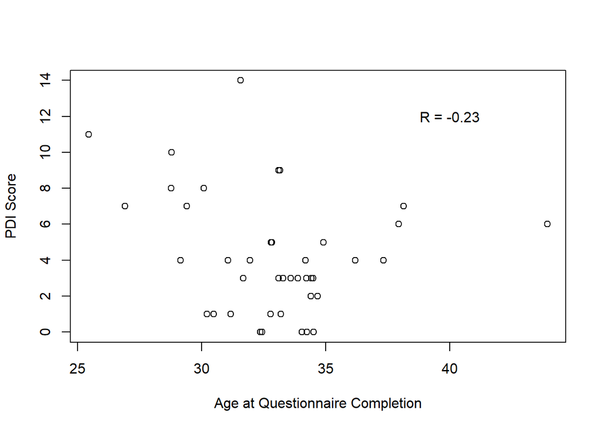

```r
pdiage = cor(pdi_dadb_d1_dlpfc$Age_PDI, pdi_dadb_d1_dlpfc$PDI)

plot(pdi_dadb_d1_dlpfc$Age_PDI, pdi_dadb_d1_dlpfc$PDI,
     ylab = 'PDI Score',
     xlab = 'Age at Questionnaire Completion' )
text(40, 12,paste0('R = ', round(pdiage,2)))
```

Removing the oldest individual who appears most like an outlier, the correlation strength increases slightly to R = -0.33.

We can also assess whether there is an age effect on D1 receptor BP<sub>ND</sub>

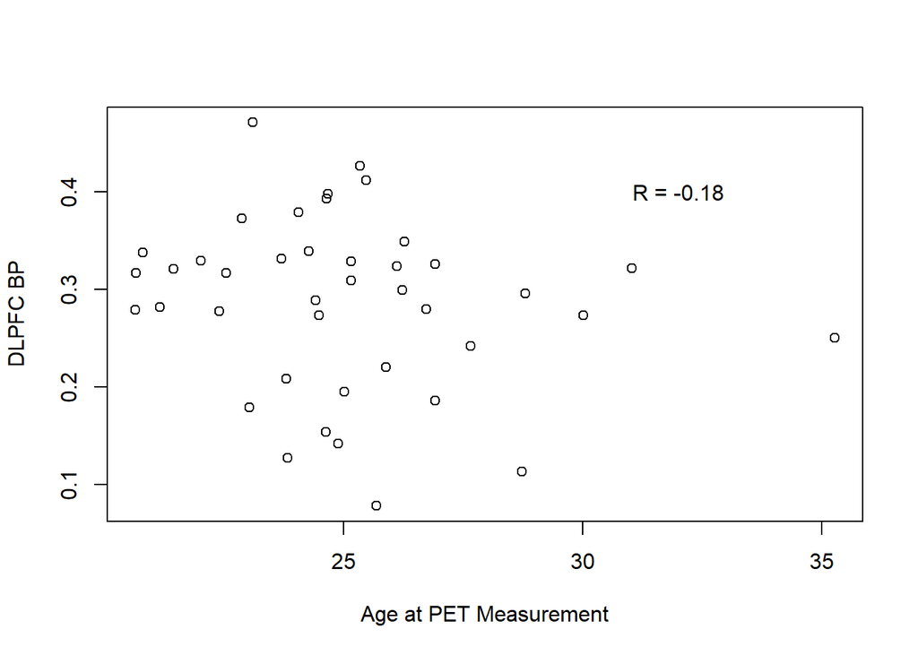

```r
d1age = cor(pdi_dadb_d1_dlpfc$Age_PET, pdi_dadb_d1_dlpfc$bp)

plot(pdi_dadb_d1_dlpfc$Age_PET, pdi_dadb_d1_dlpfc$bp,
     ylab = 'DLPFC BP',
     xlab = 'Age at PET Measurement' )
text(32, 0.4,paste0('R = ', round(d1age,2)))
```

Removing the oldest individual who appears most like an outlier, the correlation strength only changes slightly to R = -0.17.

It is concluded that in our data, we observe the same relationships between both D1 Receptor BP<sub>ND</sub> and PDI, and age. This effect is not dramatic in either group due to the limited age range of individuals examined. However, it is a known effect, and is apparent in our data. In a frequentist analysis, correction for age, given the sample size, would be likely to do more harm than good. However, if we use a Bayesian approach to this issue, we can use information which we already know from previous studies to set informative priors on the effects of age on D1 Receptor BP<sub>ND</sub> as well as on PDI scores such that the values can be corrected, but that the correction is not so volatile to our small sample size.

The model which we would want to define is therefore as follows:

$$BP_{ND} = \beta_{1} + \beta_{2}PETAge.c + \beta_{3}PETPDI$$
where PETPDI represents individuals’ PDI score at the time of the PET measurement, and PETAge.c represents the mean age of participants when they completed their PET measurement. In this way, we adjust measured BP<sub>ND</sub> values to make it as if all participants were the same age when they performed their PET measurements. We can define their PDI score at that same age (i.e. the centred age) as follows:

$$PETPDI = PDI \times (1 - \beta_{4}PDIAge.c)$$

where $\beta_{4}$ is the negative yearly change in PDI scores, and PDIAge.c is $PDIAge - MeanPETAge$, i.e. it is not centred with respect to its own mean value, but rather to the mean PET age, and thus reflects the correction of PDI scores to the adjusted PET age. In other words, if the mean PET age is 25, but a given participant was 30 at the time of PET, and 35 at the time of PDI completion, their PET score will be increased by 5 years’ worth of BP<sub>ND</sub> change, and their PDI score will be adjusted by 10 years’ worth of PDI change.

$$\dot{.\hspace{.03in}.}\hspace{.3in} BP_{ND} = \beta_{1} + \beta_{2}PETAge.c + \beta_{3}PDI - \beta_{3}\beta_{4}PDIAge.c \times PDI$$

## Relationship between PDI Scores and D1 Receptor BP<sub>ND</sub>

First, some summary statistics

```r
kable(psych::describe(pdi_dadb_d1_dlpfc$PDI), digits = 2)
```

|  | vars | n | mean | sd | median | trimmed | mad | min | max | range | skew | kurtosis | se |
| --- | --- | --- | --- | --- | --- | --- | --- | --- | --- | --- | --- | --- | --- |
| X1 | 1 | 41 | 4.24 | 3.33 | 4 | 3.94 | 2.97 | 0 | 14 | 14 | 0.81 | 0.19 | 0.52 |

```r
kable(psych::describe(pdi_dadb_d1_dlpfc$bp), digits = 2)
```

|  | vars | n | mean | sd | median | trimmed | mad | min | max | range | skew | kurtosis | se |
| --- | --- | --- | --- | --- | --- | --- | --- | --- | --- | --- | --- | --- | --- |
| X1 | 1 | 41 | 0.29 | 0.09 | 0.3 | 0.29 | 0.06 | 0.08 | 0.47 | 0.39 | -0.4 | -0.31 | 0.01 |

```r
kable(psych::describe(pdi_dadb_d1$bp[pdi_dadb_d1$Region=="gmfslSTR"]), digits = 2)
```

|  | vars | n | mean | sd | median | trimmed | mad | min | max | range | skew | kurtosis | se |
| --- | --- | --- | --- | --- | --- | --- | --- | --- | --- | --- | --- | --- | --- |
| X1 | 1 | 41 | 1.53 | 0.25 | 1.55 | 1.54 | 0.22 | 0.82 | 2.02 | 1.2 | -0.58 | 0.19 | 0.04 |

We tested the relationship between D1 Receptor BP<sub>ND</sub> and PDI scores. Our primary region of interest was the DLPFC. Our secondary region of interest is the striatum. Since the frontal cortex, and more specifically the dorsolateral prefrontal cortex, has previously been most related to psychosis, we can use priors derived from the literature and test the relative explanatory value of these different hypotheses.

The data is plotted below:

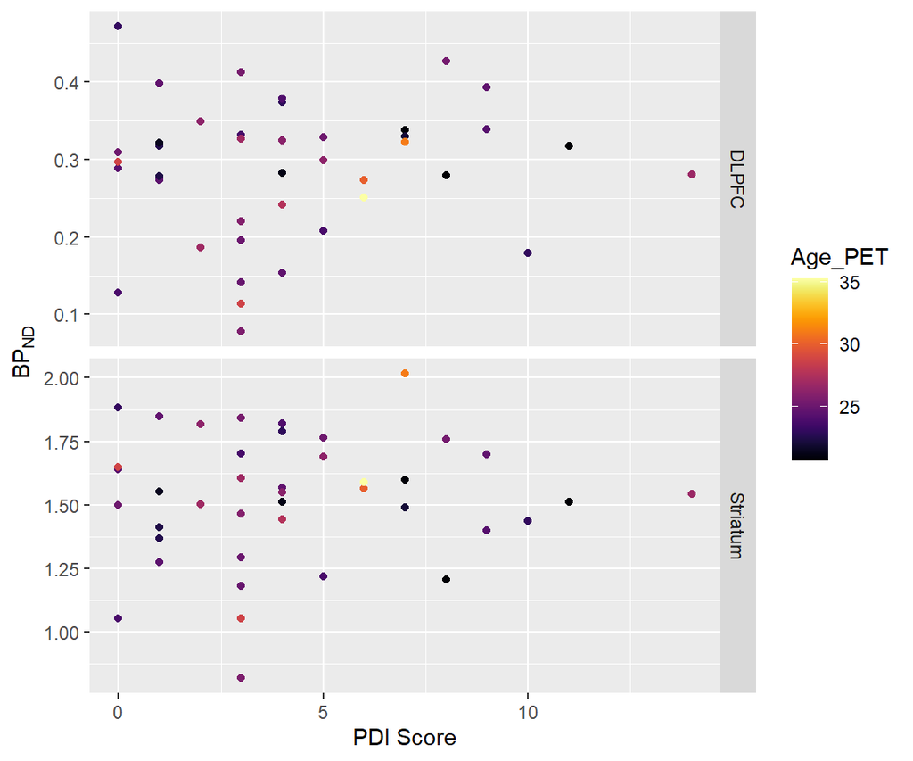

```r
pdi_dadb_d1 %>%
  mutate(Region = gsub('DLPFC_46', 'DLPFC', Region)) %>%
  mutate(Region = gsub('gmfslSTR', 'Striatum', Region)) %>%
  ggplot(., aes(x=PDI, y=bp, colour=Age_PET)) +
  geom_point() +
  ylab(expression(BP[ND])) + xlab('PDI Score') +
  viridis::scale_color_viridis(begin=0, option = 'B') +
  facet_grid(Region ~ ., scales = 'free_y')
```

We can specify this model using JAGs. We specify the following models:

## Variables for the Models

```r
bp_dlpfc <- pdi_dadb_d1$bp[pdi_dadb_d1$Region == 'DLPFC_46']
bp_str <- pdi_dadb_d1$bp[pdi_dadb_d1$Region == 'gmfslSTR']
n = length(pdi_dadb_d1_dlpfc$bp)
Age.c = pdi_dadb_d1_dlpfc$Age_PET - mean(pdi_dadb_d1_dlpfc$Age_PET)
PDI = pdi_dadb_d1_dlpfc$PDI
PDIAge.c = pdi_dadb_d1_dlpfc$Age_PDI - mean(pdi_dadb_d1_dlpfc$Age_PET)

beta2_dlpfc_mean <- mean(bp_dlpfc)*(dlpfc_age_mean)
beta2_dlpfc_sd   <- mean(bp_dlpfc)*(dlpfc_age_sd)

beta4_mean <- pdiyear_mean
beta4_sd   <- pdiyear_sd
```

## DLPFC : decrease Model

```r
beta3_decrease_sd <- (0.185*mean(bp_dlpfc))/5


parameters = c('mu', 'sigma', 'beta1', 'beta2', 'beta3', 'beta4')

dlpfc_data = list("bp_dlpfc", "n", "Age.c", "PDI", "PDIAge.c",
                  "beta2_dlpfc_mean", "beta2_dlpfc_sd",
                  "beta3_decrease_sd",
                  "beta4_mean", "beta4_sd")

myinits <- list(
  list(beta1 = runif(1,-5,5),
       beta2 = rnorm(1,beta2_dlpfc_mean,1/beta2_dlpfc_sd^2),
       beta3 = -abs(rnorm(1,0,1/beta3_decrease_sd^2)),
       beta4 = -abs(rnorm(1,beta4_mean,1/beta4_sd^2)),
       sigma = runif(1,0,100)),
  list(beta1 = runif(1,-5,5),
       beta2 = rnorm(1,beta2_dlpfc_mean,1/beta2_dlpfc_sd^2),
       beta3 = -abs(rnorm(1,0,1/beta3_decrease_sd^2)),
       beta4 = -abs(rnorm(1,beta4_mean,1/beta4_sd^2)),
       sigma = runif(1,0,100)),
  list(beta1 = runif(1,-5,5),
       beta2 = rnorm(1,beta2_dlpfc_mean,1/beta2_dlpfc_sd^2),
       beta3 = -abs(rnorm(1,0,1/beta3_decrease_sd^2)),
       beta4 = -abs(rnorm(1,beta4_mean,1/beta4_sd)),
       sigma = runif(1,0,100)))
```

Setting up the model itself:

```r
DLPFC_decrease_modelstring <- "model{

# Data and Likelihood
  for(i in 1:n){
    bp_dlpfc[i] ~ dnorm(mu[i], lambda)
    mu[i] <- beta1 + beta2*Age.c[i] + beta3*PDI[i] - beta3*beta4*PDIAge.c[i]*PDI[i]
  }

# Prior for betas
  beta1 ~ dunif( -5 , 5 )
  beta2 ~ dnorm( beta2_dlpfc_mean , pow(beta2_dlpfc_sd, -2) )
  beta3 ~ dnorm( 0 , pow(beta3_decrease_sd, -2))T(,0)
  beta4 ~ dnorm( beta4_mean , pow(beta4_sd, -2) )T(,0)

# Prior for the variance
  lambda <- pow(sigma, -2)
  sigma ~ dunif(0, 100)
}"
```

And now, to run the model:

```r
DLPFC_decrease_model <- jags(dlpfc_data, inits = myinits, parameters.to.save = parameters,
                 model.file=textConnection(DLPFC_decrease_modelstring), n.chains=3, n.iter=50000,
         n.burnin=500, DIC=T)
```

[output not shown]

To check that models fitted correctly, we can visualise the traceplots for each of the beta parameters

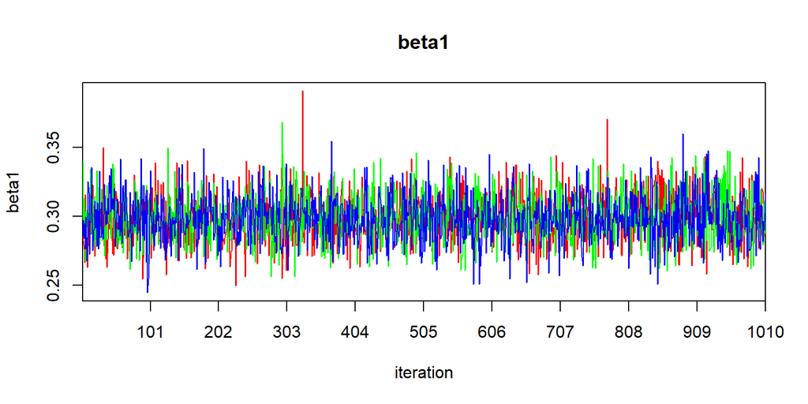

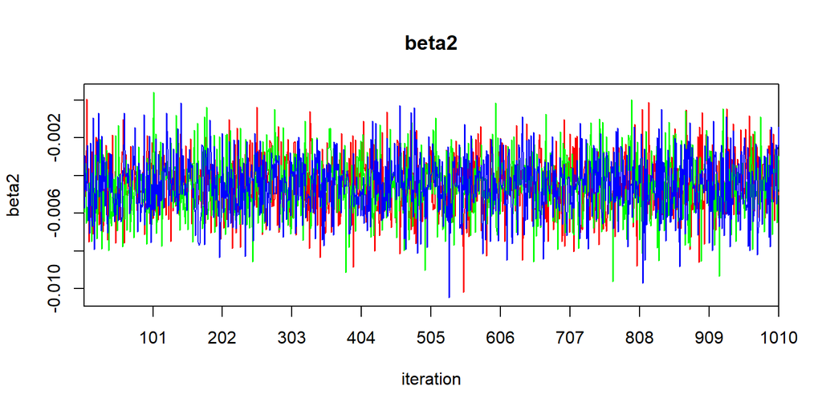

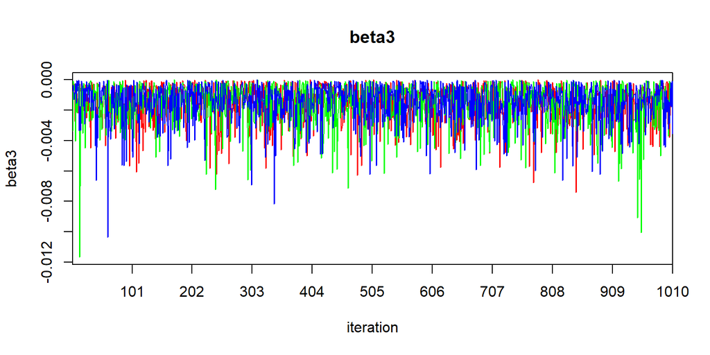

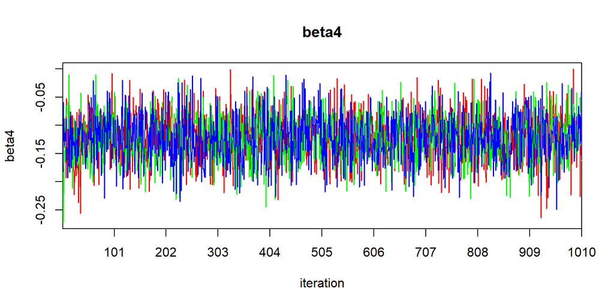

```r
for(i in 1:4) {
  traceplot(DLPFC_decrease_model, varname=paste0('beta',i), ask=F)
}
```

From these, it is concluded that the model performed adequately, as there is no apparent non-stationarity.

Now, we can check the correction parameters, to make sure that posterior estimates seem reasonable

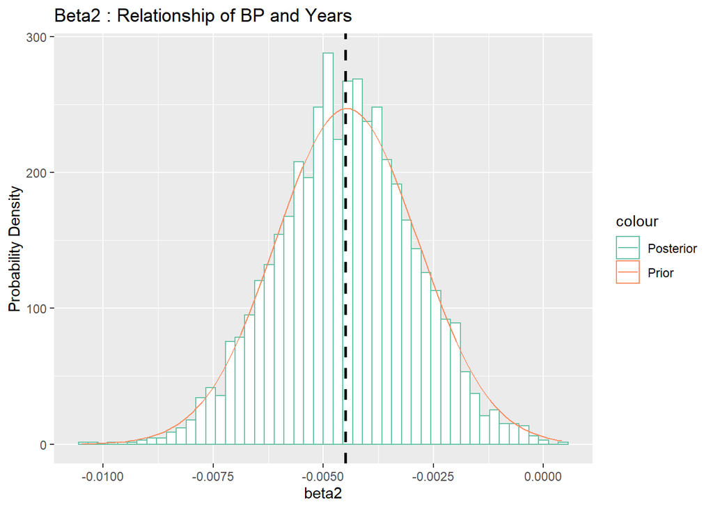

```r
betas <- data.frame(beta1 = DLPFC_decrease_model$BUGSoutput$sims.list$beta1,
                    beta2 = DLPFC_decrease_model$BUGSoutput$sims.list$beta2,
                    beta3 = DLPFC_decrease_model$BUGSoutput$sims.list$beta3,
                    beta4 = DLPFC_decrease_model$BUGSoutput$sims.list$beta4)

ggplot(betas, aes(x=beta2)) +
  #geom_density(aes(colour = "Posterior")) +
  geom_histogram(aes(y = ..density.., colour="Posterior"), bins=50, fill="white") +
  stat_function(fun = dnorm, args = list(mean = beta2_dlpfc_mean, sd=beta2_dlpfc_sd), aes(colour='Prior')) +
  geom_vline(xintercept=mean(betas$beta2), linetype = "dashed", size=1) +
  scale_colour_brewer(palette = "Set2") +
  labs(title='Beta2 : Relationship of BP and Years',y='Probability Density')
```

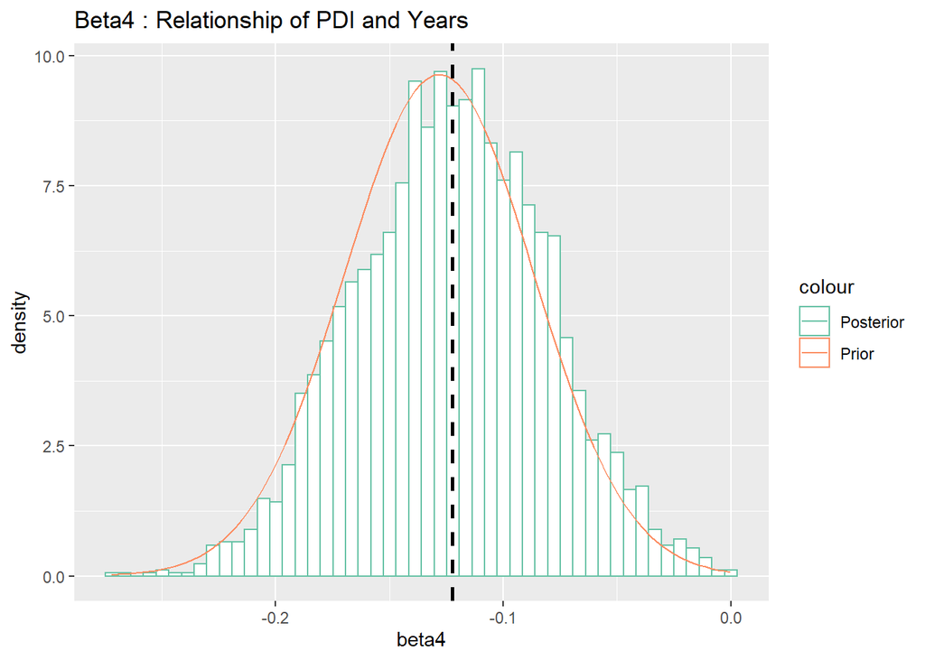

```r
ggplot(betas, aes(x=beta4)) +
  geom_histogram(aes(y = ..density.., colour="Posterior"), bins=50, fill="white") +
  stat_function(fun = dnorm, args = list(mean = beta4_mean, sd=beta4_sd), aes(colour='Prior')) +
  geom_vline(xintercept=mean(betas$beta4), linetype = "dashed", size=1) +
  scale_colour_brewer(palette = "Set2") +
  labs(title='Beta4 : Relationship of PDI and Years')
```

For beta3, the parameter of interest here, we wish to use the Savage Dickey approximation to calculate the Bayes factor.

```r
fit.posterior <- logspline(betas$beta3, ubound=0)

posterior <- dlogspline(0, fit.posterior) # this gives the pdf at point delta = 0
prior     <- 2*dnorm(0,0,beta3_decrease_sd)
BF01      <- posterior/prior
BF01
```

```
## [1] 6.832391
```

This means that the null hypothesis is 6.83 times more likely than the alternative hypothesis given the data (and assuming equal prior model odds), that there is an effect of the size specified in the decrease prior, and that the Bayes Factor for the alternative hypothesis is 0.1464

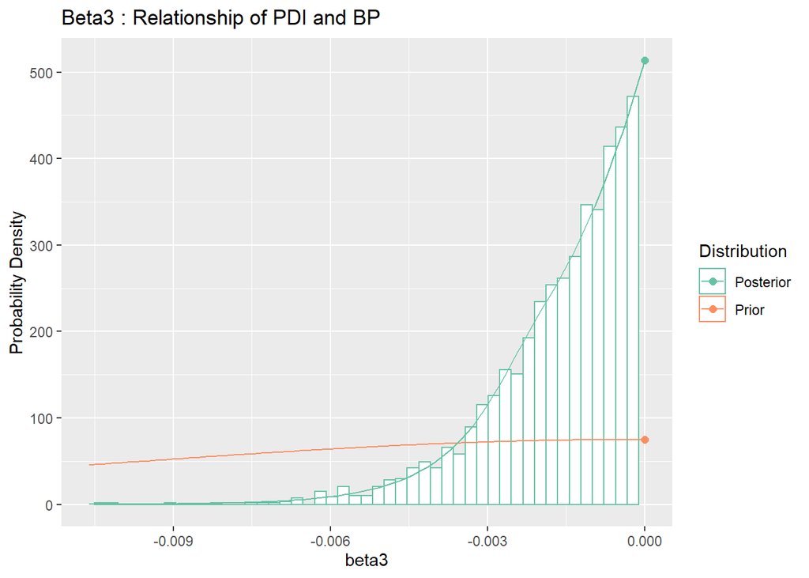

```r
savagedickey_dlpfc_decrease <- data.frame(
  Values = c(posterior,prior),
  Distribution = c('Posterior', 'Prior'),
  Model = 'Decrease'
)

ggplot(betas, aes(x=beta3)) +
  geom_histogram(aes(y = ..density.., colour="Posterior"), bins=49, fill="white") +
  stat_function(fun = dtruncnorm, args = list(mean = 0, sd=beta3_decrease_sd,a=-Inf, b=0), aes(colour='Prior')) +
  scale_colour_brewer(palette = "Set2", 'Distribution') +
  xlim(c(-beta3_decrease_sd, 0)) +
  stat_function(fun = dlogspline, args=list(fit=fit.posterior), aes(colour='Posterior')) +
  geom_point(data=savagedickey_dlpfc_decrease, aes(x=0,y=Values, colour=Distribution), size=2) +
  labs(title='Beta3 : Relationship of PDI and BP',
       y='Probability Density')
```

## DLPFC : increase Model

```r
beta3_increase_sd <- (0.185*mean(bp_dlpfc))/5


parameters = c('mu', 'sigma', 'beta1', 'beta2', 'beta3', 'beta4')

dlpfc_data = list("bp_dlpfc", "n", "Age.c", "PDI", "PDIAge.c",
                  "beta2_dlpfc_mean", "beta2_dlpfc_sd",
                  "beta3_increase_sd",
                  "beta4_mean", "beta4_sd")

myinits <- list(
  list(beta1 = runif(1,-5,5),
       beta2 = rnorm(1,beta2_dlpfc_mean,1/beta2_dlpfc_sd^2),
       beta3 = -abs(rnorm(1,0,1/beta3_increase_sd^2)),
       beta4 = -abs(rnorm(1,beta4_mean,1/beta4_sd^2)),
       sigma = runif(1,0,100)),
  list(beta1 = runif(1,-5,5),
       beta2 = rnorm(1,beta2_dlpfc_mean,1/beta2_dlpfc_sd^2),
       beta3 = -abs(rnorm(1,0,1/beta3_increase_sd^2)),
       beta4 = -abs(rnorm(1,beta4_mean,1/beta4_sd^2)),
       sigma = runif(1,0,100)),
  list(beta1 = runif(1,-5,5),
       beta2 = rnorm(1,beta2_dlpfc_mean,1/beta2_dlpfc_sd^2),
       beta3 = -abs(rnorm(1,0,1/beta3_increase_sd^2)),
       beta4 = -abs(rnorm(1,beta4_mean,1/beta4_sd^2)),
       sigma = runif(1,0,100)))
```

Setting up the model itself:

```r
DLPFC_increase_modelstring <- "model{

# Data and Likelihood
  for(i in 1:n){
    bp_dlpfc[i] ~ dnorm(mu[i], lambda)
    mu[i] <- beta1 + beta2*Age.c[i] + beta3*PDI[i] - beta3*beta4*PDIAge.c[i]*PDI[i]
  }

# Prior for betas
  beta1 ~ dunif( -5 , 5 )
  beta2 ~ dnorm( beta2_dlpfc_mean , pow(beta2_dlpfc_sd, -2) )
  beta3 ~ dnorm( 0 , pow(beta3_increase_sd, -2))T(0,)
  beta4 ~ dnorm( beta4_mean , pow(beta4_sd, -2) )T(,0)

# Prior for the variance
  lambda <- pow(sigma, -2)
  sigma ~ dunif(0, 100)
}"
```

And now, to run the model:

```r
DLPFC_increase_model <- jags(dlpfc_data, inits = myinits, parameters.to.save = parameters,
                 model.file=textConnection(DLPFC_increase_modelstring), n.chains=3, n.iter=50000,
         n.burnin=500, DIC=T)
```

[output not shown]

To check that models fitted correctly, we can visualise the traceplots for each of the beta parameters

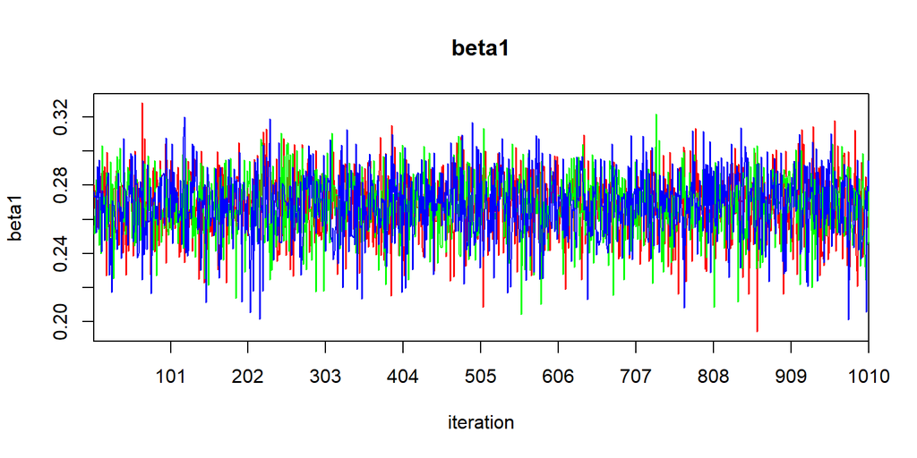

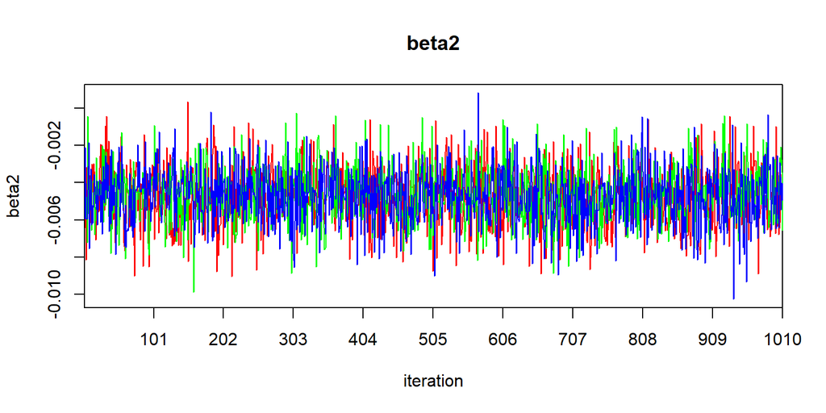

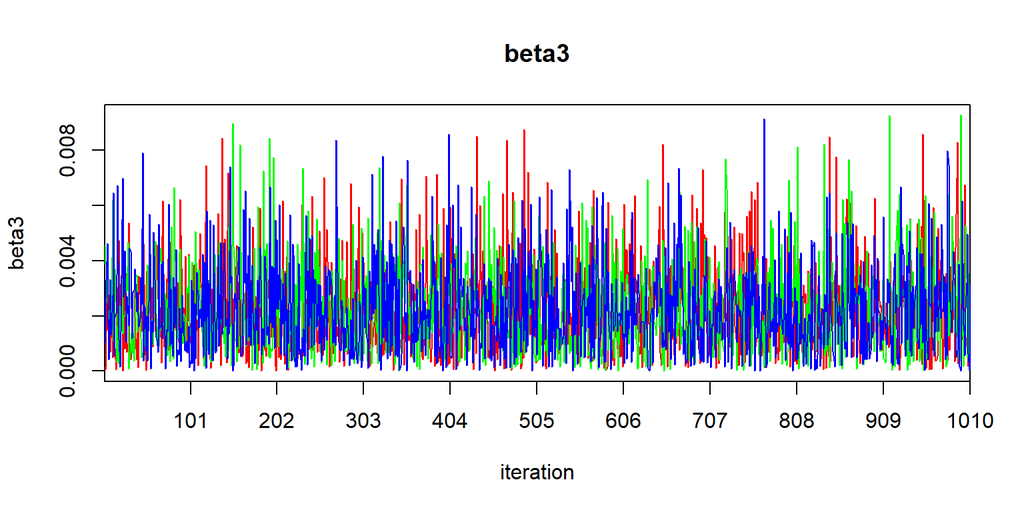

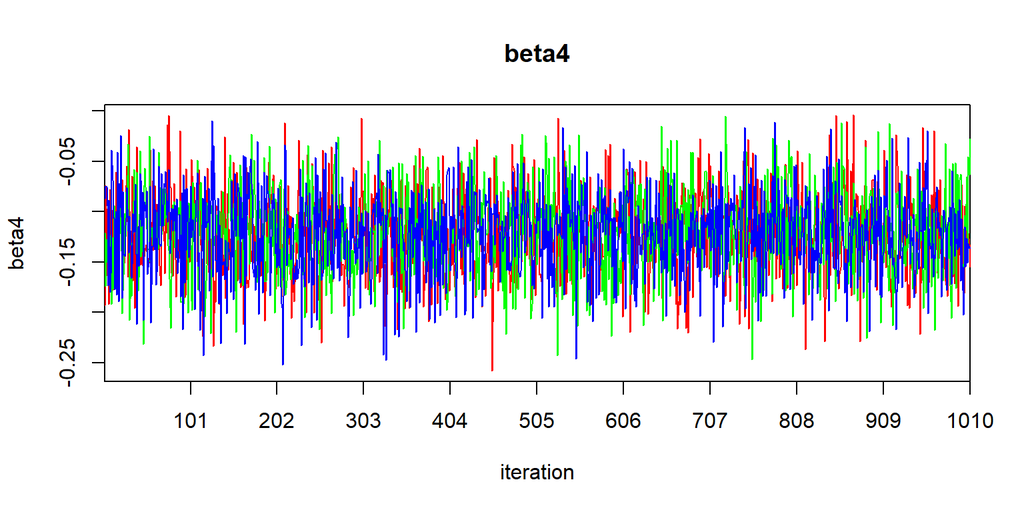

```r
for(i in 1:4) {
  traceplot(DLPFC_increase_model, varname=paste0('beta',i), ask=F)
}
```

From these, it is concluded that the model performed adequately, as there is no apparent non-stationarity.

Now, we can check the correction parameters, to make sure that posterior estimates seem reasonable

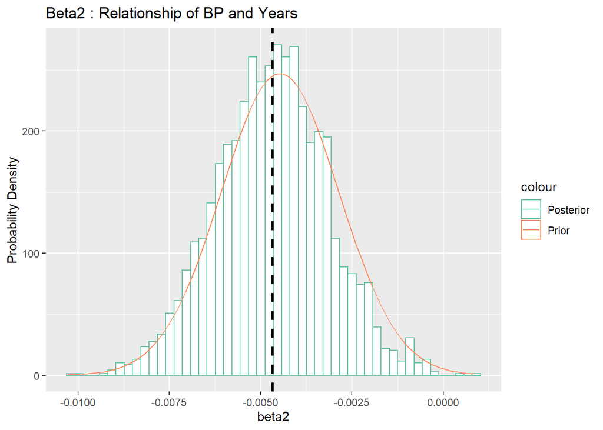

```r
betas <- data.frame(beta1 = DLPFC_increase_model$BUGSoutput$sims.list$beta1,
                    beta2 = DLPFC_increase_model$BUGSoutput$sims.list$beta2,
                    beta3 = DLPFC_increase_model$BUGSoutput$sims.list$beta3,
                    beta4 = DLPFC_increase_model$BUGSoutput$sims.list$beta4)

ggplot(betas, aes(x=beta2)) +
  #geom_density(aes(colour = "Posterior")) +
  geom_histogram(aes(y = ..density.., colour="Posterior"), bins=50, fill="white") +
  stat_function(fun = dnorm, args = list(mean = beta2_dlpfc_mean, sd=beta2_dlpfc_sd), aes(colour='Prior')) +
  geom_vline(xintercept=mean(betas$beta2), linetype = "dashed", size=1) +
  scale_colour_brewer(palette = "Set2") +
  labs(title='Beta2 : Relationship of BP and Years',y='Probability Density')
```

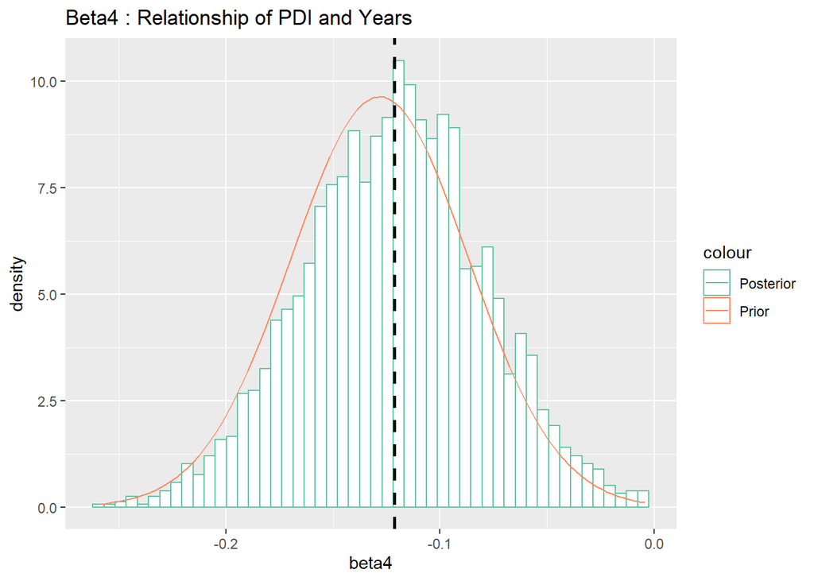

```r
ggplot(betas, aes(x=beta4)) +
  geom_histogram(aes(y = ..density.., colour="Posterior"), bins=50, fill="white") +
  stat_function(fun = dnorm, args = list(mean = beta4_mean, sd=beta4_sd), aes(colour='Prior')) +
  geom_vline(xintercept=mean(betas$beta4), linetype = "dashed", size=1) +
  scale_colour_brewer(palette = "Set2") +
  labs(title='Beta4 : Relationship of PDI and Years')
```

For beta3, the parameter of interest here, we wish to use the Savage Dickey approximation to calculate the Bayes factor.

```r
fit.posterior <- logspline(betas$beta3, lbound = 0)

posterior <- dlogspline(0, fit.posterior) # this gives the pdf at point delta = 0
prior     <- 2*dnorm(0,0,beta3_increase_sd)
BF01      <- posterior/prior
BF01
```

```
## [1] 3.378931
```

This means that the null hypothesis is 3.38 times more likely than the alternative hypothesis, given the data, that there is an effect of the size specified in the increase prior, and that the Bayes Factor for the alternative hypothesis is 0.296

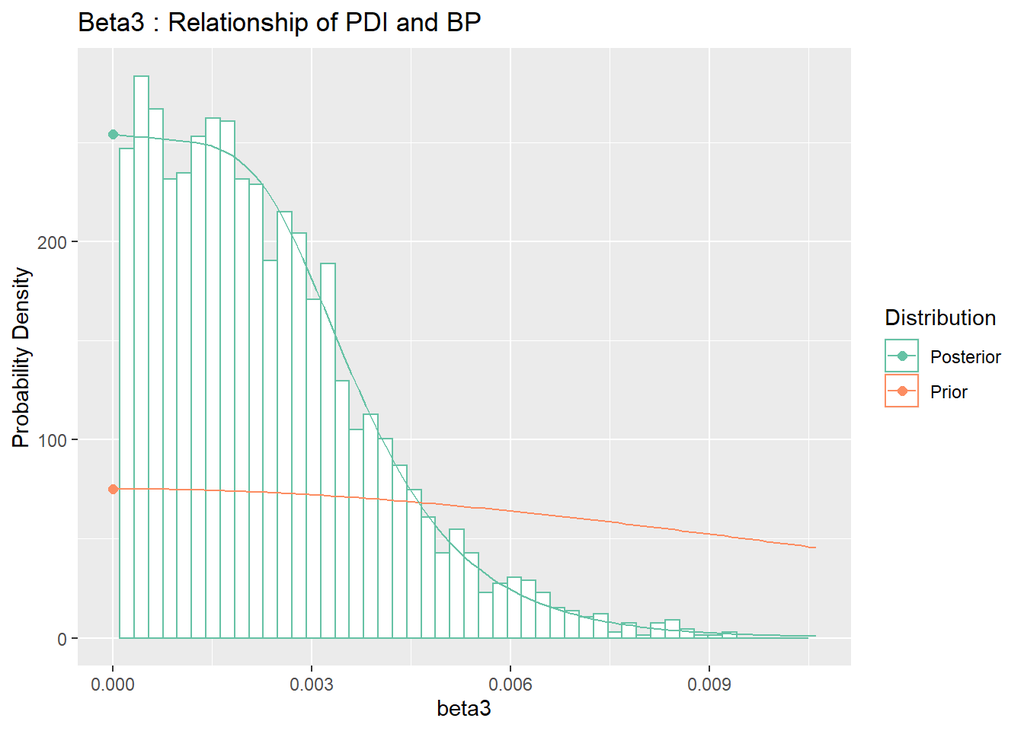

```r
savagedickey_dlpfc_increase <- data.frame(
  Values = c(posterior,prior),
  Distribution = c('Posterior', 'Prior'),
  Model = 'Increase'
)

ggplot(betas, aes(x=beta3)) +
  geom_histogram(aes(y = ..density.., colour="Posterior"), bins=50, fill="white") +
  stat_function(fun = dtruncnorm, args = list(mean = 0, sd=beta3_increase_sd,a=0, b=Inf), aes(colour='Prior')) +
  scale_colour_brewer(palette = "Set2", 'Distribution') +
  xlim(c(0,beta3_increase_sd)) +
  stat_function(fun = dlogspline, args=list(fit=fit.posterior), aes(colour='Posterior')) +
  geom_point(data=savagedickey_dlpfc_increase, aes(x=0,y=Values, colour=Distribution), size=2) +
  labs(title='Beta3 : Relationship of PDI and BP',
       y='Probability Density')
```

## Model Comparison

Now we wish to compare all of these models

```r
savagedickeys_dlpfc <- bind_rows(savagedickey_dlpfc_decrease,
                                 savagedickey_dlpfc_increase) %>%
  spread(Distribution, Values)
savagedickeys_dlpfc$BF01 <- savagedickeys_dlpfc$Posterior / savagedickeys_dlpfc$Prior
savagedickeys_dlpfc <- savagedickeys_dlpfc[,c(1,4)]
savagedickeys_dlpfc <- rbind(savagedickeys_dlpfc,
                             c('Null', 1))

modelcompare <- expand.grid(Model = savagedickeys_dlpfc$Model, ModelAgainst=savagedickeys_dlpfc$Model)

for(i in 1:nrow(modelcompare)) {
  modelcompare$BF[i] <- as.numeric(savagedickeys_dlpfc$BF01[savagedickeys_dlpfc$Model==as.character(modelcompare$ModelAgainst[i])]) /
                        as.numeric(savagedickeys_dlpfc$BF01[savagedickeys_dlpfc$Model==as.character(modelcompare$Model[i])])
}

modelcompare <- spread(modelcompare, ModelAgainst, BF) %>%
  mutate_if(is.numeric, funs(round(.,3)))
pandoc.table(modelcompare, digits=3)
```

```
##
## ----------------------------------------
##   Model     Decrease   Increase   Null
## ---------- ---------- ---------- -------
##  Decrease      1        0.495     0.146
##
##  Increase     2.02        1       0.296
##
##    Null       6.83       3.38       1
## ----------------------------------------
```

Here we see the Bayes Factor of each model against each other. The null model is the leading model, with medium to strong evidence.

```r
kable(modelcompare, format='latex', caption = 'Bayes Factors comparing each hypothesis (rows) against each other hypothesis (columns)', booktabs=T)
```

## DLPFC: Parameter Estimation

An alternative way by which to have examined this relationship is to use Bayesian parameter estimation. This involves using a prior and the data itself to derive a new estimation of the plausible relationship between BP<sub>ND</sub> and PDI scores. This can be assessed using the same model as above, but using a single prior. Since the null hypothesis is more likely than any of the two alternative hypotheses, the estimate can reasonably be assumed to lie within the bounds of these priors. Thus, I use the widest of the two to define the width of the (un-truncated) normal distribution which will be our regularising prior.

```r
beta3_parest_sd <- abs(beta3_increase_sd)


parameters = c('mu', 'sigma', 'beta1', 'beta2', 'beta3', 'beta4')

dlpfc_data = list("bp_dlpfc", "n", "Age.c", "PDI", "PDIAge.c",
                  "beta2_dlpfc_mean", "beta2_dlpfc_sd",
                  "beta3_parest_sd",
                  "beta4_mean", "beta4_sd")

myinits <- list(
  list(beta1 = runif(1,-5,5),
       beta2 = rnorm(1,beta2_dlpfc_mean,1/beta2_dlpfc_sd^2),
       beta3 = rnorm(1,0,1/beta3_parest_sd^2),
       beta4 = -abs(rnorm(1,beta4_mean,1/beta4_sd^2)),
       sigma = runif(1,0,100)),
  list(beta1 = runif(1,-5,5),
       beta2 = rnorm(1,beta2_dlpfc_mean,1/beta2_dlpfc_sd^2),
       beta3 = rnorm(1,0,1/beta3_parest_sd^2),
       beta4 = -abs(rnorm(1,beta4_mean,1/beta4_sd^2)),
       sigma = runif(1,0,100)),
  list(beta1 = runif(1,-5,5),
       beta2 = rnorm(1,beta2_dlpfc_mean,1/beta2_dlpfc_sd^2),
       beta3 = rnorm(1,0,1/beta3_parest_sd^2),
       beta4 = -abs(rnorm(1,beta4_mean,1/beta4_sd^2)),
       sigma = runif(1,0,100)))
```

Setting up the model itself:

```r
DLPFC_parest_modelstring <- "model{

# Data and Likelihood
  for(i in 1:n){
    bp_dlpfc[i] ~ dnorm(mu[i], lambda)
    mu[i] <- beta1 + beta2*Age.c[i] + beta3*PDI[i] - beta3*beta4*PDIAge.c[i]*PDI[i]
  }

# Prior for betas
  beta1 ~ dunif( -5 , 5 )
  beta2 ~ dnorm( beta2_dlpfc_mean , pow(beta2_dlpfc_sd, -2) )
  beta3 ~ dnorm( 0 , pow(beta3_parest_sd, -2))
  beta4 ~ dnorm( beta4_mean , pow(beta4_sd, -2) )T(,0)

# Prior for the variance
  lambda <- pow(sigma, -2)
  sigma ~ dunif(0, 100)
}"
```

And now, to run the model:

```r
DLPFC_parest_model <- jags(dlpfc_data, inits = myinits, parameters.to.save = parameters,
                 model.file=textConnection(DLPFC_parest_modelstring), n.chains=3, n.iter=50000,
         n.burnin=500, n.thin=2)
```

[output not shown]

To check that models fitted correctly, we can visualise the traceplots for each of the beta parameters

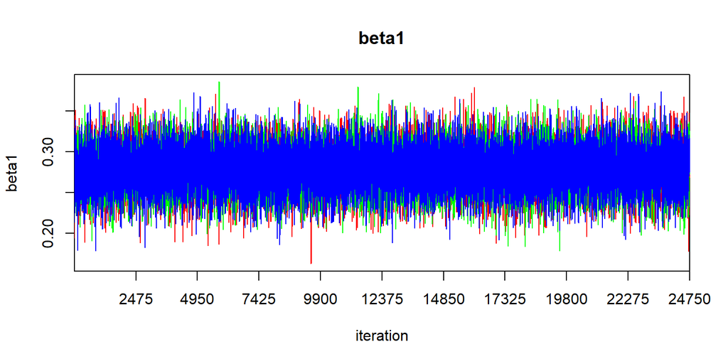

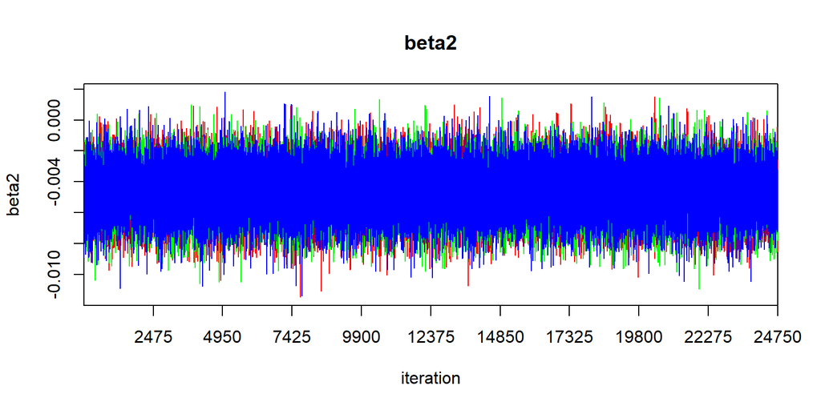

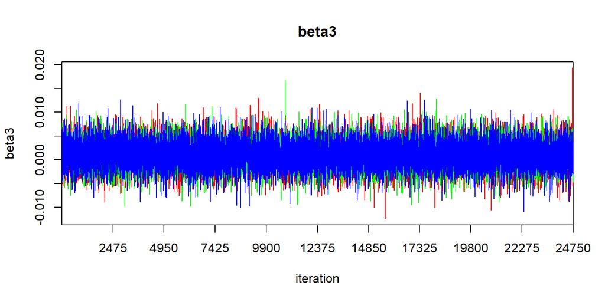

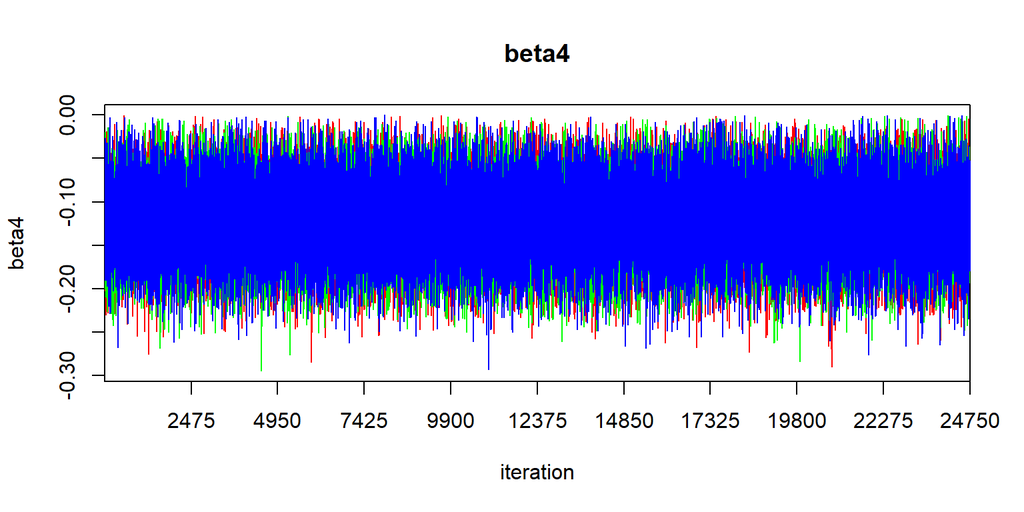

```r
for(i in 1:4) {
  traceplot(DLPFC_parest_model, varname=paste0('beta',i), ask=F)
}
```

From these, it is concluded that the model performed adequately, as there is no apparent non-stationarity.

Now, we can check the correction parameters, to make sure that posterior estimates seem reasonable

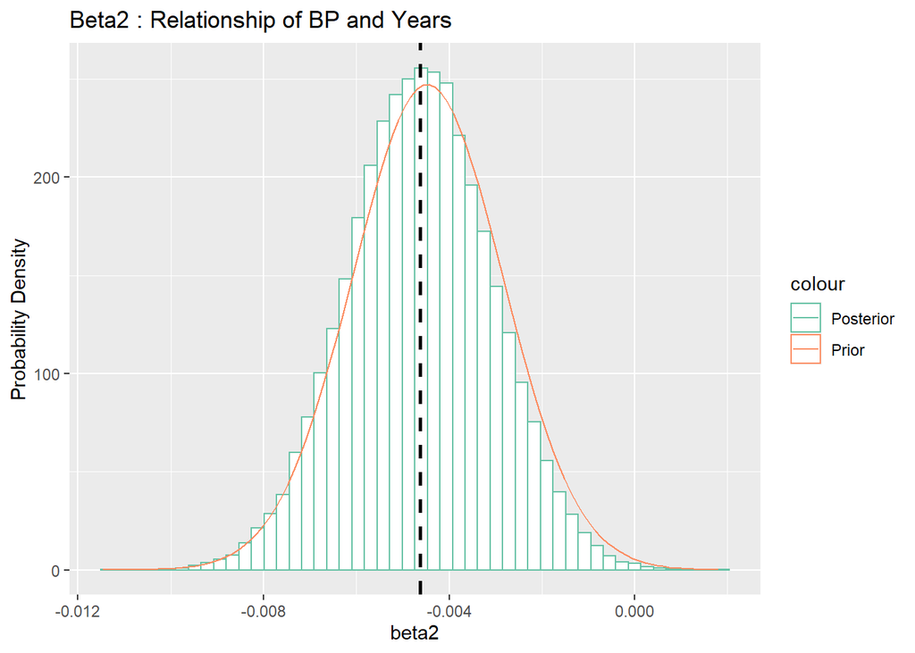

```r
betas <- data.frame(beta1 = DLPFC_parest_model$BUGSoutput$sims.list$beta1,
                    beta2 = DLPFC_parest_model$BUGSoutput$sims.list$beta2,
                    beta3 = DLPFC_parest_model$BUGSoutput$sims.list$beta3,
                    beta4 = DLPFC_parest_model$BUGSoutput$sims.list$beta4)

ggplot(betas, aes(x=beta2)) +
  #geom_density(aes(colour = "Posterior")) +
  geom_histogram(aes(y = ..density.., colour="Posterior"), bins=50, fill="white") +
  stat_function(fun = dnorm, args = list(mean = beta2_dlpfc_mean, sd=beta2_dlpfc_sd), aes(colour='Prior')) +
  geom_vline(xintercept=mean(betas$beta2), linetype = "dashed", size=1) +
  scale_colour_brewer(palette = "Set2") +
  labs(title='Beta2 : Relationship of BP and Years',y='Probability Density')
```

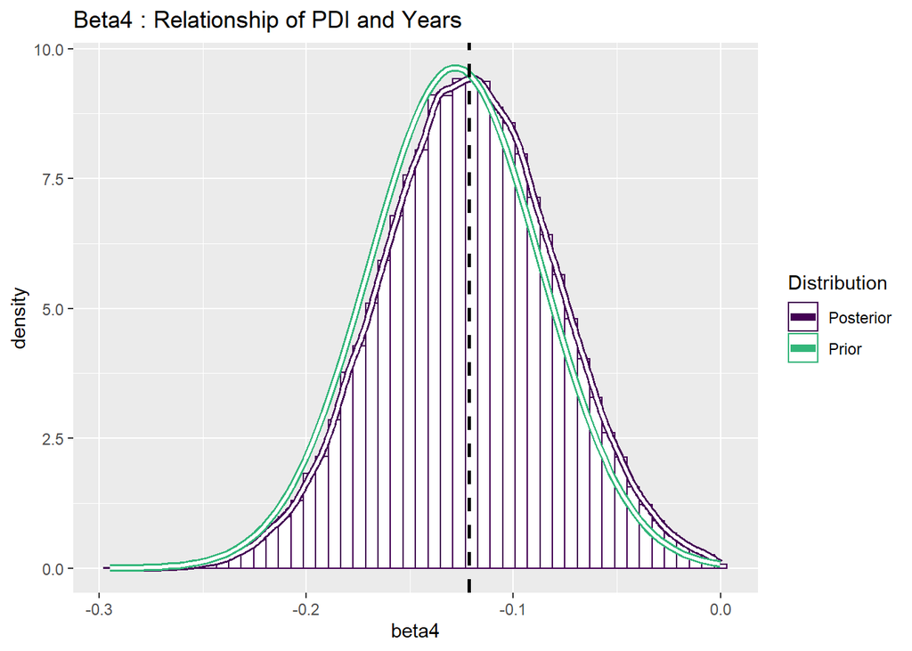

```r
ggplot(betas, aes(x=beta4)) +
  geom_histogram(aes(y = ..density.., colour="Posterior"), bins=50, fill="white") +
  geom_line(aes(y = ..density.., colour="Posterior"), size=2, stat="density") +
  geom_line(aes(y = ..density..), colour="white", size=1, stat="density") +
  stat_function(fun = dnorm, args = list(mean = beta4_mean, sd=beta4_sd), aes(colour='Prior'), size=2) +
  stat_function(fun = dnorm, args = list(mean = beta4_mean, sd=beta4_sd), color="white", size=1) +
  geom_vline(xintercept=mean(betas$beta4), linetype = "dashed", size=1) +
  # scale_colour_brewer(palette = "Set2") +
  scale_colour_viridis(begin=0,direction=1, end=0.66, discrete=T, 'Distribution') +
  labs(title='Beta4 : Relationship of PDI and Years')
```

We will save the details of these posteriors for the covariates to use as priors in Substudy 6

```r
( beta2_dlpfc_mean_update <- mean(betas$beta2) / mean(bp_dlpfc) )
```

```
## [1] -0.01614
```

```r
( beta2_dlpfc_sd_update <- sd(betas$beta2) / mean(bp_dlpfc) )
```

```
## [1] 0.00540196
```

```r
( beta4_dlpfc_mean_update <- mean(betas$beta4) )
```

```
## [1] -0.1215805
```

```r
( beta4_dlpfc_sd_update <- sd(betas$beta4) )
```

```
## [1] 0.04164544
```

For beta3, the parameter of interest here, our estimate is as follows:

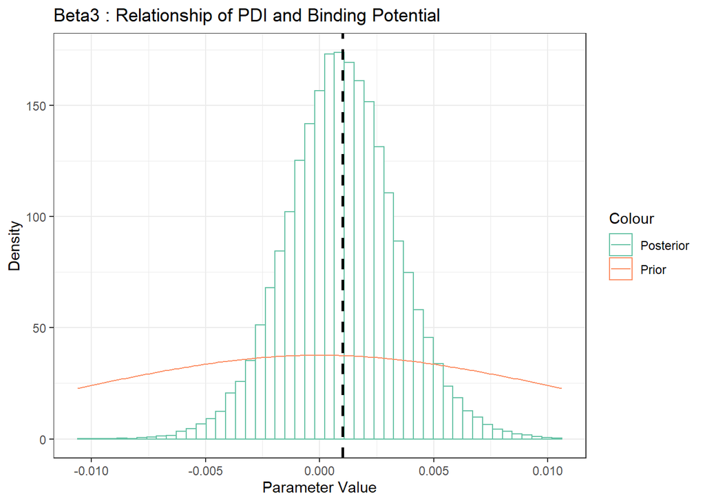

```r
beta3_parestplot <- ggplot(betas, aes(x=beta3)) +
  geom_histogram(aes(y = ..density.., colour="Posterior"), bins=50, fill="white") +
  stat_function(fun = dnorm, args = list(mean = 0, sd=beta3_parest_sd), aes(colour='Prior')) +
  geom_vline(xintercept=mean(betas$beta3), linetype = "dashed", size=1) +
  scale_colour_brewer(palette = "Set2", "Colour") +
  lims(x=c(-beta3_parest_sd, beta3_parest_sd)) +
  labs(title='Beta3 : Relationship of PDI and Binding Potential') +
  theme_bw() +
  labs(y='Density',
       x='Parameter Value')
beta3_parestplot
```

```r
library(MCMCvis)

dlpfc_parest_summary <- as.data.frame(MCMCvis::MCMCsummary(DLPFC_parest_model, params = c('beta1', 'beta2', 'beta3', 'beta4'), digits=3))
```